# Tutorial 7: Discovering Nutritional Groups in Food Data with Clustering

CHEE4003: Special Topics A - Artificial Intelligence in Chemical Engineering

Published

October 8, 2026

# What is clustering?

In Tutorial 6, we used **Principal Component Analysis (PCA)** to explore patterns in the Australian Food Composition Database. PCA reduced hundreds of nutritional measurements to a small number of principal components, making it easier to visualise similarities and differences between foods. Although some food groups appeared to separate in the PCA plots, PCA does not explicitly identify groups within the data. Instead, it provides a low-dimensional representation that highlights the major sources of variation among samples.

**Clustering** is a family of unsupervised learning techniques that identifies groups of similar samples without using a target variable. Unlike PCA, which represents samples using new coordinates, clustering assigns samples to groups defined by an algorithm. The goal is to discover meaningful structure within the data by placing similar observations into the same cluster.

There is no single definition of a cluster. Different algorithms make different assumptions about the underlying structure of the data, which can lead to different groupings of the same dataset. In this tutorial, we will compare three commonly used clustering approaches:

| Algorithm | Cluster definition | Required parameters |
| --- | --- | --- |
| K-means | Points closer to their own centre than to any other centre | Number of clusters, $k$ |
| DBSCAN | A connected region of sufficient sample density | Neighbourhood radius `eps` and density threshold `min_samples` |
| Gaussian mixture | Samples represented by a weighted set of probability distributions | Number of components |

Each method defines similarity in a different way. K-means partitions samples into compact groups around cluster centres, DBSCAN (*Density-Based Spatial Clustering of Applications with Noise*) identifies dense regions separated by sparse areas and can label isolated samples as outliers, while Gaussian mixture models describe clusters as overlapping probability distributions. Understanding these assumptions is important when selecting an appropriate clustering method and interpreting its results.

**NoteLearning Objectives**

After completing this tutorial, you will be able to:

1. fit and interpret K-means, DBSCAN, and Gaussian mixture models;
2. select and assess clustering parameters using internal and external measures;
3. explain how cluster shape and density assumptions affect the results; and
4. distinguish hard clustering, density-based clustering, and probabilistic assignment.

# Exploring the food composition database

The dataset used in this tutorial is the same Australian Food Composition Database introduced in Tutorial 6. After removing variables containing missing values, the dataset contains **1,588 foods** and **60 complete nutritional analytes**. These variables describe the nutritional composition of each food, including macronutrients, minerals, vitamins, amino acids, and fatty acids.

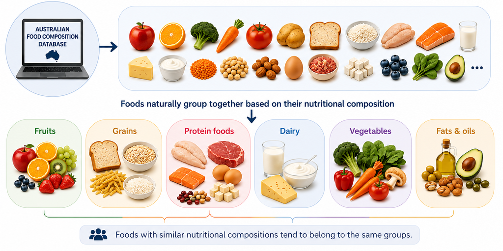

Figure 1: Example food categories represented in the dataset.

As illustrated in Figure 1, foods with similar nutritional compositions often form natural groups within the data. Clustering algorithms seek to identify these groups directly from nutritional measurements without using predefined labels, allowing us to investigate whether meaningful food categories can be recovered from composition alone.

Download the dataset to get started:

```
ausnat_food_composition.csv
```

```
Public Food Key,Classification,Derivation,Food Name,Food Group,"Energy with dietary fibre, equated (kJ)","Energy, without dietary fibre, equated (kJ)",Moisture (water) (g),Protein (g),Nitrogen (g),"Fat, total (g)",Ash (g),Total dietary fibre (g),Alcohol (g),Fructose (g),Glucose (g),Sucrose (g),Maltose (g),Lactose (g),Galactose (g),Total sugars (g),Added sugars (g),Free sugars (g),Starch (g),Dextrin (g),Glycerol (g),Glycogen (g),Inulin (g),Erythritol (g),Maltitol (g),Mannitol (g),Xylitol (g),Maltodextrin (g),Oligosaccharides (g),Polydextrose (g),Raffinose (g),Stachyose (g),Sorbitol (g),Resistant starch (g),"Available carbohydrate, without sugar alcohols (g)","Available carbohydrate, with sugar alcohols (g)",Acetic acid (g),Citric acid (g),Fumaric acid (g),Lactic acid (g),Malic acid (g),Oxalic acid (g),Propionic acid (g),Quinic acid (g),Shikimic acid (g),Succinic acid (g),Tartaric acid (g),Aluminium (Al) (ug),Antimony (Sb) (ug),Arsenic (As) (ug),Cadmium (Cd) (ug),Calcium (Ca) (mg),Chromium (Cr) (ug),Chloride (Cl) (mg),Cobalt (Co) (ug),Copper (Cu) (mg),Fluoride (F) (ug),Iodine (I) (ug),Iron (Fe) (mg),Lead (Pb) (ug),Magnesium (Mg) (mg),Manganese (Mn) (mg),Mercury (Hg) (ug),Molybdenum (Mo) (ug),Nickel (Ni) (ug),Phosphorus (P) (mg),Potassium (K) (mg),Selenium (Se) (ug),Sodium (Na) (mg),Sulphur (S) (mg),Tin (Sn) (ug),Zinc (Zn) (mg),Retinol (preformed vitamin A) (ug),Alpha-carotene (ug),Beta-carotene (ug),Cryptoxanthin (ug),Beta-carotene equivalents (provitamin A) (ug),Vitamin A retinol equivalents (ug),Lutein (ug),Lycopene (ug),Xanthophyl (ug),Thiamin (B1) (mg),Riboflavin (B2) (mg),Niacin (B3) (mg),Niacin derived from tryptophan (mg),Niacin derived equivalents (mg),Pantothenic acid (B5) (mg),Pyridoxine (B6) (mg),Biotin (B7) (ug),Cobalamin (B12) (ug),"Folate, natural (ug)",Folic acid (ug),Total folates (ug),Dietary folate equivalents (ug),Vitamin C (mg),Cholecalciferol (D3) (ug),Ergocalciferol (D2) (ug),25-hydroxy cholecalciferol (25-OH D3) (ug),25-hydroxy ergocalciferol (25-OH D2) (ug),Vitamin D3 equivalents (ug),Alpha tocopherol (mg),Alpha tocotrienol (mg),Beta tocopherol (mg),Beta tocotrienol (mg),Delta tocopherol (mg),Delta tocotrienol (mg),Gamma tocopherol (mg),Gamma tocotrienol (mg),Vitamin E (mg),C4 (%T),C6 (%T),C8 (%T),C10 (%T),C11 (%T),C12 (%T),C13 (%T),C14 (%T),C15 (%T),C16 (%T),C17 (%T),C18 (%T),C19 (%T),C20 (%T),C21 (%T),C22 (%T),C23 (%T),C24 (%T),"Total saturated fatty acids, equated (%T)",C12:1 (%T),C14:1 (%T),C15:1 (%T),C16:1 (%T),C17:1 (%T),C18:1 (%T),C18:1w7 (%T),C20:1 (%T),C20:1w11 (%T),C22:1 (%T),C22:1w11 (%T),C24:1 (%T),"Total monounsaturated fatty acids, equated (%T)",C12:2 (%T),C16:2w4 (%T),C16:3 (%T),C18:2w6 (%T),C18:3w3 (%T),C18:3w4 (%T),C18:3w6 (%T),C18:4w1 (%T),C18:4w3 (%T),C20:2 (%T),C20:2w6 (%T),C20:4 (%T),C20:3w3 (%T),C20:3w6 (%T),C20:4w3 (%T),C20:4w6 (%T),C20:5w3 (%T),C21:5w3 (%T),C22:2 (%T),C22:2w6 (%T),C22:4w6 (%T),C22:5w3 (%T),C22:5w6 (%T),C22:6w3 (%T),"Total polyunsaturated fatty acids, equated (%T)","Total long chain omega 3 fatty acids, equated (%T)",Total undifferentiated fatty acids (%T),"Total trans fatty acids, imputed (%T)",C4 (g),C6 (g),C8 (g),C10 (g),C11 (g),C12 (g),C13 (g),C14 (g),C15 (g),C16 (g),C17 (g),C18 (g),C19 (g),C20 (g),C21 (g),C22 (g),C23 (g),C24 (g),"Total saturated fatty acids, equated (g)",C12:1 (g),C14:1 (g),C15:1 (g),C16:1 (g),C17:1 (g),C18:1 (g),C18:1w7 (g),C20:1 (g),C20:1w11 (mg),C22:1 (g),C22:1w11 (mg),C24:1 (g),"Total monounsaturated fatty acids, equated (g)",C12:2 (g),C16:2w4 (mg),C16:3 (g),C18:2w6 (g),C18:3w3 (g),C18:3w4 (g),C18:3w6 (mg),C18:4w1 (g),C18:4w3 (mg),C20:2 (mg),C20:2w6 (mg),C20:3 (mg),C20:3w3 (mg),C20:3w6 (mg),C20:4 (g),C20:4w3 (mg),C20:4w6 (mg),C20:5w3 (mg),C21:5w3 (g),C22:5w3 (mg),C22:4w6 (mg),C22:2 (g),C22:2w6 (mg),C22:5w6 (g),C22:6w3 (mg),"Total polyunsaturated fatty acids, equated (g)","Total long chain omega 3 fatty acids, equated (mg)","Total undifferentiated fatty acids, mass basis (mg)","Total trans fatty acids, imputed (mg)",Caffeine (mg),Cholesterol (mg),Alanine (mg/gN),Arginine (mg/gN),Aspartic acid (mg/gN),Cystine plus cysteine (mg/gN),Glutamic acid (mg/gN),Glycine (mg/gN),Histidine (mg/gN),Isoleucine (mg/gN),Leucine (mg/gN),Lysine (mg/gN),Methionine (mg/gN),Phenylalanine (mg/gN),Proline (mg/gN),Serine (mg/gN),Threonine (mg/gN),Tyrosine (mg/gN),Tryptophan (mg/gN),Valine (mg/gN),Alanine (mg),Arginine (mg),Aspartic acid (mg),Cystine plus cysteine (mg),Glutamic acid (mg),Glycine (mg),Histidine (mg),Isoleucine (mg),Leucine (mg),Lysine (mg),Methionine (mg),Phenylalanine (mg),Proline (mg),Serine (mg),Threonine (mg),Tyrosine (mg),Tryptophan (mg),Valine (mg)
F002258,31302,Borrowed,"Cardamom seed, dried, ground",Other,1236,1012,8.3,10.8,1.72,6.7,5.8,28.0,0.0,,,,,,,4.4,0.0,0.0,30.0,,,,,,,,,,,,,,,,34.4,34.4,,,,,,,,,,,,,,,,383,,,,,,0.0,13.97,,229,,,,,178,1119,11.7,18,,,7.47,0,,22,,22,4,,,,0.198,0.182,1.1,2.64,3.74,,0.23,,0.0,3,0,3,3,21,0.0,0.0,0.0,0.0,0.0,2.8,,,,,,,,2.85,,,,,,,,,,,,,,,,,,,34.34,,,,,,,,,,,,,43.94,,,,15.6,6.1,,,,,,,,,,,,0.0,,,,,0.0,,0.0,21.72,0.0,,0.0,,,,,,,,,,,,,,,,,,,2.2,,,,,,,,,,,,,2.81,,,,1.0,0.39,,,,,,,,,,,,,0.0,,0.0,,,,,0.0,1.39,0.0,,0.0,0,0,,,,,,,,,,,,,,,,,90.0,,,,,,,,,,,,,,,,,,155,
F002963,31302,Borrowed,"Cinnamon, dried, ground",Other,1004,579,10.6,4.0,0.64,1.2,3.6,53.1,0.0,,,,,,,2.2,0.0,0.0,25.3,,,,,,,,,,,,,,,,27.5,27.5,,,,,,,,,,,,,,,,1002,,,,,,0.1,8.32,,60,,,,,64,431,3.1,10,,,1.83,0,,112,,112,19,,,,0.022,0.041,1.33,0.83,2.16,,0.16,,0.0,6,0,6,6,4,0.0,0.0,0.0,0.0,0.0,2.3,,,,,,,,2.32,,,,,,,,,,,,,,,,,,,52.35,,,,,,,,,,,,,37.33,,,,6.7,1.7,,,,,,,,,,,,0.0,,,,,0.0,,0.0,10.32,0.0,,0.0,,,,,,,,,,,,,,,,,,,0.62,,,,,,,,,,,,,0.44,,,,0.08,0.02,,,,,,,,,,,,,0.0,,0.0,,,,,0.0,0.12,0.0,,0.0,0,0,,,,,,,,,,,,,,,,,77.0,,,,,,,,,,,,,,,,,,49,
F002893,31302,Borrowed,"Chilli (chili), dried, ground",Other,1224,950,10.8,12.3,2.0,14.3,8.5,34.2,0.0,,,,,,,7.2,0.0,0.0,5.7,,,,,,,,,,,,,,,,12.9,12.9,,,,,,,,,,,,,,,,278,,,,,,2.3,14.3,,170,,,,,303,1920,8.6,68,,,2.7,0,2090.0,15000,,16045,2674,,,,0.35,0.79,10.0,1.09,11.09,,1.9,,0.0,100,0,100,100,64,0.0,0.0,0.0,0.0,0.0,1.0,,,,,,,,1.0,,,,,,,,,,,,,,,,,,,18.0,,,,,,,,,,,,,23.47,,,,54.6,3.9,,,,,,,,,,,,0.0,,,,,0.0,,0.0,58.53,0.0,,0.0,,,,,,,,,,,,,,,,,,,2.06,,,,,,,,,,,,,2.68,,,,6.25,0.45,,,,,,,,,,,,,0.0,,0.0,,,,,0.0,6.7,0.0,,0.0,0,0,,,,,,,,,,,,,,,,,32.0,,,,,,,,,,,,,,,,,,64,
F002970,31302,Borrowed,"Cloves, dried, ground",Other,1389,1118,9.9,6.0,0.96,13.0,5.6,33.9,0.0,,,,,,,2.4,0.0,0.0,29.2,,,,,,,,,,,,,,,,31.6,31.6,,,,,,,,,,,,,,,,632,,,,,,50.7,11.83,,259,,,,,104,1020,7.2,277,,,2.32,0,,45,,45,8,,,,0.216,0.22,1.56,0.51,2.07,,0.39,,0.0,25,0,25,25,0,0.0,0.0,0.0,0.0,0.0,8.8,,,,,,,,8.82,,,,,,,,,,,,,,,,,,,44.15,,,,,,,,,,,,,15.56,,,,29.7,6.5,,,,,,,,,,,,0.1,,,,,2.0,,0.0,40.45,2.145,,0.0,,,,,,,,,,,,,,,,,,,5.49,,,,,,,,,,,,,1.93,,,,3.69,0.81,,,,,,,,,,,,,11.06,,255.52,,,,,0.0,5.03,266.581,,0.0,0,0,,,,,,,,,,,,,,,,,31.0,,,,,,,,,,,,,,,,,,30,
... (1585 more lines)
```

Recall from Tutorial 6 that the first few columns contain information used to identify and categorise each food, while the remaining columns contain nutritional measurements.

| Column | Description |
| --- | --- |
| Public Food Key | Unique identifier assigned to each food item in the database |
| Classification | Food classification code used within the database |
| Derivation | Source of the nutritional data (analysed, borrowed, imputed, or recipe-based) |
| Food Name | Name of the food item |
| Food Group | Broad food category derived from the classification code |
| *268 additional columns* | Nutritional measurements including energy, macronutrients, minerals, vitamins, individual fatty acids, and amino acids |

Recall from Tutorial 6 that the `Food Group` column provides an expert classification of foods based on their nutritional characteristics:

pd.read_csv('data/ausnat_food_composition.csv')["Food Group"].value_counts()

Food Group

Other 425

Meat & poultry 355

Vegetables 252

Cereals 163

Fruit 143

Fish & seafood 115

Milk products 56

Seeds & nuts 41

Fats & oils 38

Name: count, dtype: int64

In this tutorial, the `Food Group` categories are *withheld during clustering* and used later as reference labels. Because clustering is an unsupervised learning task, these labels are not used when fitting the models. Instead, they support external evaluation of the clustering results.

## Data preparation

Before anything else, we need to have the correct libraries imported. Copy the following code into your script to import the necessary libraries:

```
import_libraries.py
```

```python
import numpy as np
import pandas as pd
import matplotlib.pyplot as plt
from matplotlib.patches import Ellipse
from sklearn.preprocessing import StandardScaler
from sklearn.decomposition import PCA
from sklearn.cluster import KMeans, DBSCAN
from sklearn.mixture import GaussianMixture
from sklearn.neighbors import NearestNeighbors
from sklearn.model_selection import train_test_split
from sklearn.metrics import (silhouette_score, adjusted_rand_score,
                             confusion_matrix, accuracy_score)
```

The preprocessing from Tutorial 6 is collected in one function. It removes identifying columns, discards analytes containing missing values, applies a logarithmic transformation, standardises the analytes and retains seven principal components.

**TipApplying `PCA()` with `fit_transform()`**

In Tutorial 6, we calculated the principal components manually using matrix algebra to understand how PCA works. Here, we use scikit-learn’s `PCA()` class, which performs the same calculations automatically.

Many scikit-learn objects use a two-step process: **`fit()`** learns information from the data, while **`transform()`** applies that information to the data. The convenience method **`fit_transform()`** combines both steps into a single command.

For example, `StandardScaler().fit_transform()` learns how to scale each analyte and then applies the scaling, while `pca.fit_transform()` learns the principal component directions and projects the data onto those components to produce the principal component scores.

For more information, see the [scikit-learn PCA documentation](https://scikit-learn.org/stable/modules/generated/sklearn.decomposition.PCA.html).

```
load_and_reduce.py
```

```python
LABELS = ["Public Food Key", "Classification", "Derivation", "Food Name", "Food Group"]

def load_and_reduce(file_path, n_components=7):
    """
    Load the food data, apply the Tutorial 6 preprocessing, and reduce it with PCA.

    Parameters
    ----------
    file_path : str
        The path to the CSV file containing the dataset.
    n_components : int, optional
        How many principal components to keep (default is 7).

    Returns
    -------
    scores : np.ndarray
        The component scores, one row per food.
    X : pd.DataFrame
        The standardised log-transformed analyte table.
    names : pd.Series
        The name of each food.
    groups : pd.Series
        The reference food group of each food, used only for evaluation.
    """
    data = pd.read_csv(file_path)

    measurements = data.drop(columns=LABELS).dropna(axis=1)
    X = pd.DataFrame(StandardScaler().fit_transform(np.log1p(measurements)),
                     columns=measurements.columns)

    pca = PCA(n_components=n_components, random_state=42)
    scores = pca.fit_transform(X)

    print(f"Foods:                {scores.shape[0]}")
    print(f"Analytes kept:        {X.shape[1]}")
    print(f"Components kept:      {n_components}")
    print(f"Variance retained:    {100 * pca.explained_variance_ratio_.sum():.1f}%")
    return scores, X, data["Food Name"], data["Food Group"]
```

scores, X, names, groups = load_and_reduce('data/ausnat_food_composition.csv')

Foods: 1588

Analytes kept: 60

Components kept: 7

Variance retained: 69.8%

The output shows that PCA has reduced the dataset from 60 analytes to seven principal components while retaining 69.8% of the original variation.

### Why cluster the principal component scores?

Distance measures often become less informative as dimensionality increases. Clustering the seven principal component scores provides a lower-dimensional representation that retains most of the information while reducing noise and redundancy.

The choice of seven components is a modelling decision for this clustering analysis, not an optimal component count for every purpose. In Tutorial 6, more components were retained because the objective was accurate reconstruction of the original data.

Although the clustering models developed in the following sections use all seven retained principal components, seven-dimensional data cannot be visualised directly. Instead, we display the first two principal component scores, which provide a useful two-dimensional summary of the overall structure of the data.

The following helper function creates scatter plots of these scores. Each point represents a food, while colours can be used to indicate food groups, cluster assignments, or other labels. These plots will be used throughout the tutorial to compare clustering results.

```
plot_clusters.py
```

```python
def plot_clusters(scores, labels, title, ax=None):
    """
    Scatter the first two components, one colour per label.

    Parameters
    ----------
    scores : np.ndarray
        The component scores, one row per food.
    labels : array-like
        A label for every food. Cluster numbers, food groups, anything.
    title : str
        The plot title.
    ax : matplotlib.axes.Axes, optional
        The axes to draw on. A new figure is made if this is left out.
    """
    if ax is None:
        _, ax = plt.subplots(figsize=(6, 6))
    labels = pd.Series(labels).reset_index(drop=True)

    # -1 is DBSCAN's flag for noise and "Other" is the database's catch-all
    # group. Both are drawn first, in grey, so the real clusters sit on top.
    background = labels.isin([-1, "Other"]).to_numpy()
    if background.any():
        ax.scatter(scores[background, 0], scores[background, 1],
                   s=8, color="lightgrey", label="Other / noise")

    for value in sorted(labels[~background].unique(), key=str):
        mask = (labels == value).to_numpy()
        ax.scatter(scores[mask, 0], scores[mask, 1], s=12, alpha=0.8, label=str(value))

    ax.set_xlabel("PC1")
    ax.set_ylabel("PC2")
    ax.set_title(title)
    ax.legend(markerscale=2, fontsize=8)
    ax.grid(True, alpha=0.3)
    plt.tight_layout()
    return ax
```

Notice that the labels supplied to `plot_clusters()` are the reference food groups. This plot serves as a benchmark that we can compare against the clustering results produced by the different algorithms later in the tutorial.

ax = plot_clusters(scores, groups, "Reference Food Groups")

plt.show()

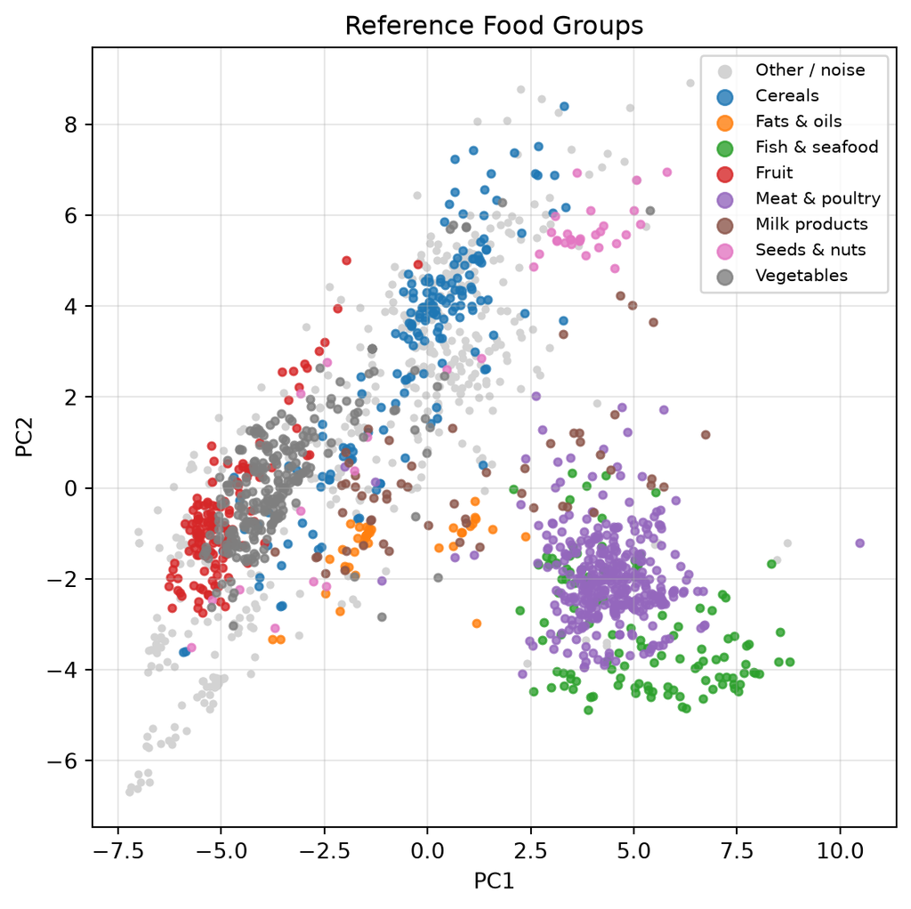

The plotting function is designed to work with both food-group labels and clustering results. Foods belonging to the `"Other"` category are displayed in grey, while DBSCAN noise points (`-1`) will also be shown in grey when we apply that algorithm later.

## Part A: K-means clustering

K-means is one of the most widely used clustering algorithms because it is simple, computationally efficient, and often provides a useful first view of the structure within a dataset. In this part, we will apply K-means to the food composition data and compare the resulting clusters with the reference food groups. First, let’s examine how the algorithm works.

**NoteK-means algorithm**

K-means partitions the data into **$k$ clusters** by locating cluster centres (called **centroids**) and assigning each sample to its nearest centre. The algorithm repeats the following steps until the assignments no longer change significantly:

1. Assign each point to its nearest centroid using Euclidean distance.
2. Update each centroid to the mean of all points assigned to that cluster.

The algorithm seeks to minimise the **inertia**,

$$J = \sum_{i=1}^{n} \lVert \mathbf{x}_i - \boldsymbol{\mu}_{c(i)} \rVert^2 ,$$

which is the total squared distance between each point and the centroid of its assigned cluster. Each iteration reduces or leaves unchanged the value of $J$, causing the algorithm to converge. However, the final solution may be a local minimum, so K-means is usually run multiple times with different starting centroids.

Because K-means uses cluster means and Euclidean distance, it works best when clusters are compact, roughly spherical, and of similar size. Every sample is assigned to a cluster, including isolated observations that may be outliers.

### Task 1 : Fit K-means

Write a function `cluster_kmeans` that fits a `KMeans` model to the principal component scores, prints the cluster sizes, and compares the resulting cluster assignments with the reference food groups using two side-by-side plots.

Begin with `k = 9`, matching the number of reference food groups. In the next task, we will evaluate this choice without using the reference labels.

**TipImplementation guidance**

Create the model using `KMeans(n_clusters=k, n_init=10, random_state=42)`. The `.fit_predict(scores)` method fits the model and returns a cluster label for each food. Setting `n_init=10` runs the algorithm from ten different starting points and retains the solution with the lowest inertia.

Use `plt.subplots(1, 2, figsize=(12, 6))` to create the comparison plots, and `np.bincount(labels)` to calculate the cluster sizes.

For more information, see the [scikit-learn KMeans documentation](https://scikit-learn.org/stable/modules/generated/sklearn.cluster.KMeans.html).

```
cluster_kmeans.py
```

```python
def cluster_kmeans(scores, groups, k=9):
    """
    Cluster the foods with K-means and compare the result with the food groups.

    Parameters
    ----------
    scores : np.ndarray
        The component scores, one row per food.
    groups : pd.Series
        The reference food group of each food, used only for the second panel.
    k : int, optional
        The number of clusters to look for (default is 9).

    Returns
    -------
    labels : np.ndarray
        The cluster number assigned to each food.
    """
```

When you run this function, it should yield the following output:

With `k=9`, K-means produces clusters of noticeably different sizes, ranging from 36 to 394 foods. This indicates that some nutritional patterns are much more common than others. However, these results do not tell us whether `k=9` is the most appropriate choice, motivating a more systematic investigation of the number of clusters in the next section.

kmeans_labels = cluster_kmeans(scores, groups, k=9)

Inertia: 17569

Cluster 0: 276 foods

Cluster 1: 394 foods

Cluster 2: 172 foods

Cluster 3: 201 foods

Cluster 4: 36 foods

Cluster 5: 152 foods

Cluster 6: 125 foods

Cluster 7: 112 foods

Cluster 8: 120 foods

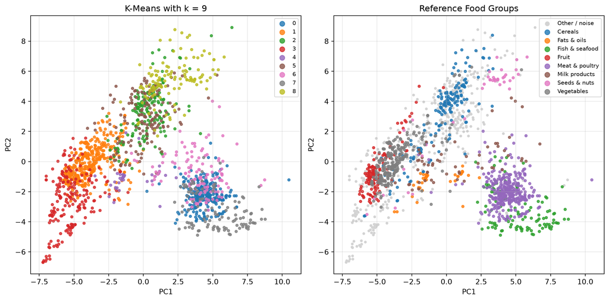

Although the clusters do not perfectly match the reference food groups, the overall similarity between the two panels suggests that K-means has identified meaningful nutritional patterns. Foods with similar nutrient profiles tend to cluster together, even though the food group labels were not used when fitting the model.

**Callout-answerAnswer**

```
cluster_kmeans.py
```

```python
def cluster_kmeans(scores, groups, k=9):
    """
    Cluster the foods with K-means and compare the result with the food groups.

    Parameters
    ----------
    scores : np.ndarray
        The component scores, one row per food.
    groups : pd.Series
        The reference food group of each food, used only for the second panel.
    k : int, optional
        The number of clusters to look for (default is 9).

    Returns
    -------
    labels : np.ndarray
        The cluster number assigned to each food.
    """
    model = KMeans(n_clusters=k, n_init=10, random_state=42)
    labels = model.fit_predict(scores)

    print(f"Inertia: {model.inertia_:.0f}\n")
    for cluster, size in enumerate(np.bincount(labels)):
        print(f"Cluster {cluster}:  {size:4d} foods")

    fig, axes = plt.subplots(1, 2, figsize=(12, 6))
    plot_clusters(scores, labels, f"K-Means with k = {k}", ax=axes[0])
    plot_clusters(scores, groups, "Reference Food Groups", ax=axes[1])
    plt.tight_layout()
    plt.show()
    return labels

kmeans_labels = cluster_kmeans(scores, groups, k=9)
```

Output

```
Inertia: 17569

Cluster 0:   276 foods
Cluster 1:   394 foods
Cluster 2:   172 foods
Cluster 3:   201 foods
Cluster 4:    36 foods
Cluster 5:   152 foods
Cluster 6:   125 foods
Cluster 7:   112 foods
Cluster 8:   120 foods
```

Output

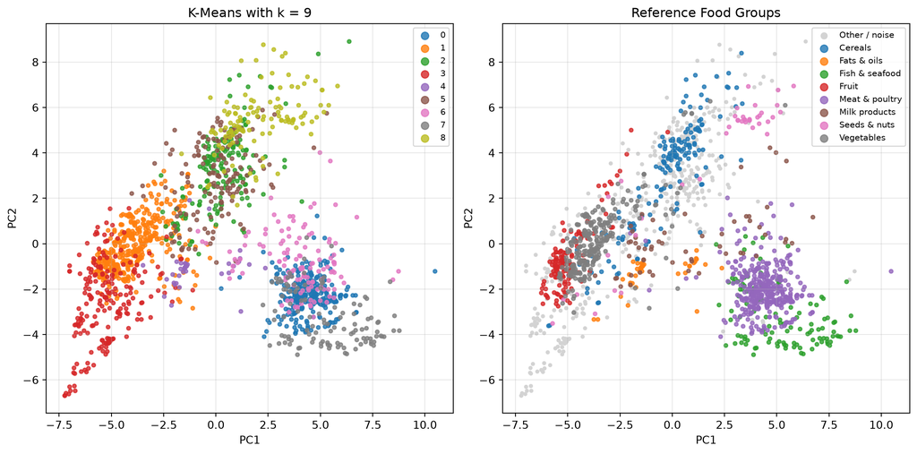

### Task 2 : Select the number of clusters

In an unsupervised analysis, $k$ must be selected without reference labels. Inertia decreases as $k$ increases, so it cannot be used on its own to select the number of clusters. Instead, the elbow heuristic looks for the point beyond which increasing $k$ produces only small reductions in inertia.

**NoteInternal evaluation measures**

The silhouette score evaluates both cluster cohesion and cluster separation. For a single sample, let

- $a$ be the average distance to other samples in the same cluster,
- $b$ be the average distance to samples in the nearest neighbouring cluster.

$$s = \frac{b - a}{\max(a, b)} \in [-1, 1].$$

A silhouette value close to 1 indicates that a sample fits well within its cluster and is well separated from neighbouring clusters. Values near 0 indicate samples that lie between clusters, while negative values may indicate poor cluster assignment. The overall silhouette score is the average across all samples.

Write a function `choose_k` that fits K-means for each $k$ from 2 to 12, records the inertia and silhouette score, plots both measures, and identifies the value of $k$ with the highest silhouette score.

**TipImplementation guidance**

`silhouette_score(scores, labels)` returns the mean silhouette. Its pairwise distance calculations can be expensive for large datasets; the optional `sample_size` argument supports approximate evaluation from a subsample.

The silhouette is undefined for $k = 1$, so the sweep begins at 2. For more information, see the [scikit-learn silhouette_score documentation](https://scikit-learn.org/stable/modules/generated/sklearn.metrics.silhouette_score.html).

```
choose_k.py
```

```python
def choose_k(scores, k_values=range(2, 13)):
    """
    Sweep the number of clusters and score each one without using labels.

    Parameters
    ----------
    scores : np.ndarray
        The component scores, one row per food.
    k_values : iterable of int, optional
        The values of k to try (default is 2 to 12).

    Returns
    -------
    best_k : int
        The k with the highest silhouette score.
    """
```

When you run this function, it should yield the following output:

best_k = choose_k(scores)

k = 2 inertia 46640 silhouette 0.306

k = 3 inertia 34778 silhouette 0.370

k = 4 inertia 29390 silhouette 0.387

k = 5 inertia 25941 silhouette 0.339

k = 6 inertia 22778 silhouette 0.346

k = 7 inertia 20770 silhouette 0.314

k = 8 inertia 18986 silhouette 0.312

k = 9 inertia 17569 silhouette 0.316

k = 10 inertia 16365 silhouette 0.286

k = 11 inertia 15497 silhouette 0.282

k = 12 inertia 14851 silhouette 0.288

Highest silhouette at k = 4

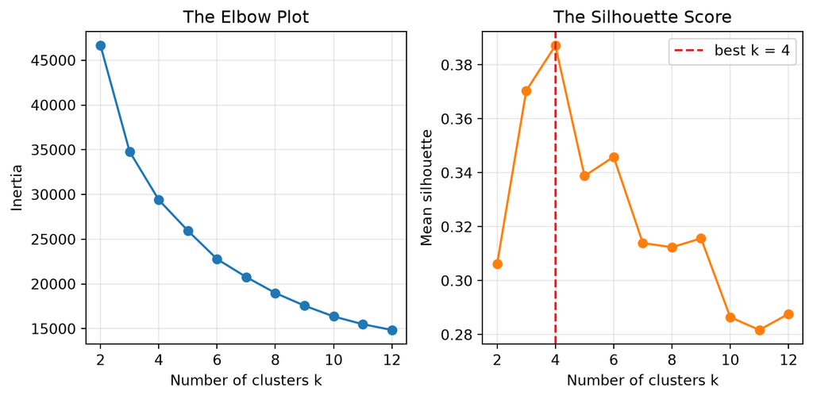

The inertia curve has no distinct elbow, while the silhouette score is highest at $k=4$. This suggests that the data contain four broad, well-separated nutritional regions rather than nine compact clusters. The next task compares this internal result with the reference food groups.

Based on these internal evaluation measures, $k=4$ appears to be a more appropriate choice than $k=9$, that does this suggest about the relationship between the expert-defined food groups and the underlying nutritional structure of the data?

**Callout-answerAnswer**

```
choose_k.py
```

```python
def choose_k(scores, k_values=range(2, 13)):
    """
    Sweep the number of clusters and score each one without using labels.

    Parameters
    ----------
    scores : np.ndarray
        The component scores, one row per food.
    k_values : iterable of int, optional
        The values of k to try (default is 2 to 12).

    Returns
    -------
    best_k : int
        The k with the highest silhouette score.
    """
    k_values = list(k_values)
    inertia, silhouette = [], []

    for k in k_values:
        model = KMeans(n_clusters=k, n_init=10, random_state=42).fit(scores)
        inertia.append(model.inertia_)
        silhouette.append(silhouette_score(scores, model.labels_))

    for k, j, s in zip(k_values, inertia, silhouette):
        print(f"k = {k:2d}   inertia {j:7.0f}   silhouette {s:.3f}")

    best_k = k_values[int(np.argmax(silhouette))]
    print(f"\nHighest silhouette at k = {best_k}")

    fig, axes = plt.subplots(1, 2, figsize=(8, 4))
    axes[0].plot(k_values, inertia, "o-")
    axes[0].set_xlabel("Number of clusters k")
    axes[0].set_ylabel("Inertia")
    axes[0].set_title("The Elbow Plot")
    axes[0].grid(True, alpha=0.3)

    axes[1].plot(k_values, silhouette, "o-", color="C1")
    axes[1].axvline(best_k, color="C3", linestyle="--", label=f"best k = {best_k}")
    axes[1].set_xlabel("Number of clusters k")
    axes[1].set_ylabel("Mean silhouette")
    axes[1].set_title("The Silhouette Score")
    axes[1].legend()
    axes[1].grid(True, alpha=0.3)
    plt.tight_layout()
    plt.show()
    return best_k

best_k = choose_k(scores)
```

Output

```
k =  2   inertia   46640   silhouette 0.306
k =  3   inertia   34778   silhouette 0.370
k =  4   inertia   29390   silhouette 0.387
k =  5   inertia   25941   silhouette 0.339
k =  6   inertia   22778   silhouette 0.346
k =  7   inertia   20770   silhouette 0.314
k =  8   inertia   18986   silhouette 0.312
k =  9   inertia   17569   silhouette 0.316
k = 10   inertia   16365   silhouette 0.286
k = 11   inertia   15497   silhouette 0.282
k = 12   inertia   14851   silhouette 0.288

Highest silhouette at k = 4
```

Output

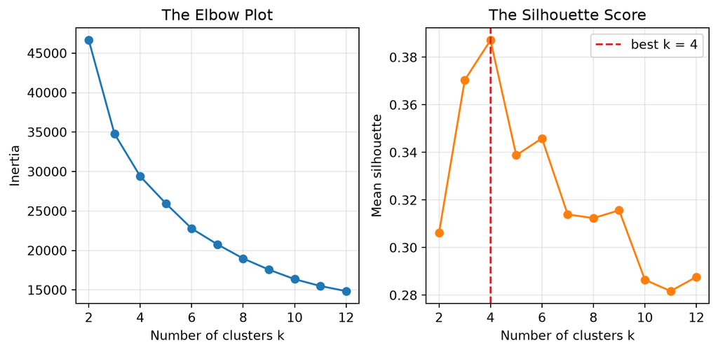

The result suggests that the underlying nutritional structure of the data may be simpler than the nine expert-defined food groups. While the food groups represent meaningful categories, some of them appear to have similar nutritional compositions and therefore occupy overlapping regions of the PCA space.

As a result, K-means identifies four broad nutritional patterns that are more distinct from one another than a partition into nine clusters. This indicates that foods from different reference groups can share similar nutrient profiles, whereas foods within the same reference group may sometimes be nutritionally diverse.

### Task 3 : Compare clusters with reference groups

In the first task, we fitted K-means with $k=9$ to match the number of reference food groups. Although the silhouette score suggested that $k=4$ provides a more natural partition of the data, the availability of reference labels allows us to investigate a different question: how closely do the clusters align with the expert-defined categories? We therefore examine the $k=9$ solution, which provides a more direct comparison with the nine food groups, and assess their agreement using the Adjusted Rand Index (ARI).

**NoteWhy ordinary accuracy is unsuitable**

Cluster labels are arbitrary. For example, one run of K-means might label a group as Cluster 0, while another labels the same group as Cluster 4. The clustering is identical, but the accuracy would change.

The Adjusted Rand Index (ARI) avoids this problem by measuring how similarly two sets of labels group the foods, regardless of the cluster numbers used.

- **ARI = 1.0** indicates perfect agreement.
- **ARI = 0.0** indicates agreement expected by chance.
- **ARI < 0** indicates worse agreement than expected by chance.

Higher ARI values indicate stronger agreement between the clustering solution and the reference food groups.

Write a function `compare_with_groups` that constructs a contingency table of cluster against food group, converts each row to percentages, draws a heatmap, and reports the ARI. Also compare the ARI and silhouette score across different values of $k$.

**TipImplementation guidance**

`pd.crosstab(labels, groups)` constructs the table. Use `table.div(table.sum(axis=1), axis=0)` to normalise each row.

Draw the heatmap with `plt.imshow` and compute the index with `adjusted_rand_score(groups, labels)`. For more information, see the [pandas pd.crosstab documentation](https://pandas.pydata.org/docs/reference/api/pandas.crosstab.html) and [scikit-learn adjusted_rand_score documentation](https://scikit-learn.org/stable/modules/generated/sklearn.metrics.adjusted_rand_score.html).

```
compare_with_groups.py
```

```python
def compare_with_groups(scores, labels, groups, k_values=range(2, 13)):
    """
    Measure how much of the food group labelling a clustering recovered.

    Parameters
    ----------
    scores : np.ndarray
        The component scores, one row per food.
    labels : np.ndarray
        The cluster number assigned to each food.
    groups : pd.Series
        The reference food group of each food.
    k_values : iterable of int, optional
        The values of k to sweep for the second panel (default is 2 to 12).

    Returns
    -------
    table : pd.DataFrame
        The contingency table of cluster against food group, as row percentages.
    """
```

When you run this function, it should yield the following output:

table = compare_with_groups(scores, kmeans_labels, groups)

Adjusted Rand Index: 0.443

Food Group Cereals Fats & oils Fish & seafood Fruit Meat & poultry Milk products Other Seeds & nuts Vegetables

row_0

0 0 0 0 0 98 0 1 0 0

1 2 0 0 25 1 3 10 1 59

2 65 0 0 1 0 1 27 2 4

3 10 1 0 20 0 0 62 3 2

4 0 92 0 0 0 0 8 0 0

5 3 0 0 2 0 11 85 0 0

6 0 2 3 0 64 21 10 0 0

7 0 0 99 0 1 0 0 0 0

8 15 0 0 1 0 0 55 23 6

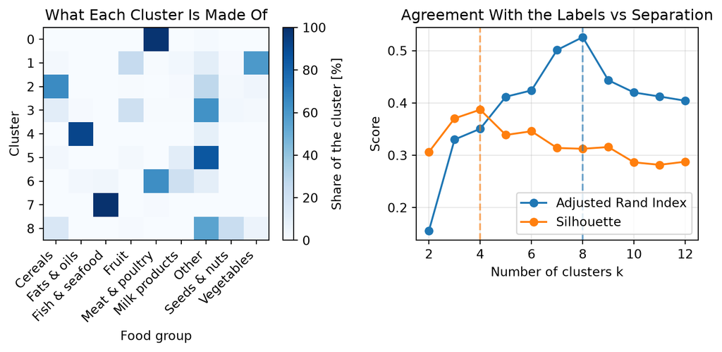

The ARI of 0.44 indicates moderate agreement between the K-means clusters and the reference food groups. Meat and poultry, fish and seafood, and fats and oils are concentrated in distinct clusters, while fruit, vegetables, and the heterogeneous `Other` category are spread across multiple clusters.

The silhouette score is highest at $k = 4$, whereas the ARI is highest at $k = 8$. Silhouette measures compactness and separation without reference labels, while ARI measures agreement with an external classification. The two measures therefore answer different questions and need not select the same $k$.

What does this difference tell us about the relationship between the reference food groups and the natural nutritional structure of the data?

**Callout-answerAnswer**

```
compare_with_groups.py
```

```python
def compare_with_groups(scores, labels, groups, k_values=range(2, 13)):
    """
    Measure how much of the food group labelling a clustering recovered.

    Parameters
    ----------
    scores : np.ndarray
        The component scores, one row per food.
    labels : np.ndarray
        The cluster number assigned to each food.
    groups : pd.Series
        The reference food group of each food.
    k_values : iterable of int, optional
        The values of k to sweep for the second panel (default is 2 to 12).

    Returns
    -------
    table : pd.DataFrame
        The contingency table of cluster against food group, as row percentages.
    """
    counts = pd.crosstab(labels, groups)
    table = 100 * counts.div(counts.sum(axis=1), axis=0)

    print(f"Adjusted Rand Index: {adjusted_rand_score(groups, labels):.3f}\n")
    print(table.round(0).astype(int).to_string())

    k_values = list(k_values)
    ari, silhouette = [], []
    for k in k_values:
        swept = KMeans(n_clusters=k, n_init=10, random_state=42).fit_predict(scores)
        ari.append(adjusted_rand_score(groups, swept))
        silhouette.append(silhouette_score(scores, swept))

    fig, axes = plt.subplots(1, 2, figsize=(8, 4))
    image = axes[0].imshow(table, cmap="Blues", vmin=0, vmax=100, aspect="auto")
    fig.colorbar(image, ax=axes[0], label="Share of the cluster [%]")
    axes[0].set_xticks(range(len(table.columns)))
    axes[0].set_xticklabels(table.columns, rotation=45, ha="right")
    axes[0].set_yticks(range(len(table.index)))
    axes[0].set_xlabel("Food group")
    axes[0].set_ylabel("Cluster")
    axes[0].set_title("What Each Cluster Is Made Of")

    axes[1].plot(k_values, ari, "o-", label="Adjusted Rand Index")
    axes[1].plot(k_values, silhouette, "o-", label="Silhouette")
    axes[1].axvline(k_values[int(np.argmax(ari))], color="C0", linestyle="--", alpha=0.6)
    axes[1].axvline(k_values[int(np.argmax(silhouette))], color="C1", linestyle="--", alpha=0.6)
    axes[1].set_xlabel("Number of clusters k")
    axes[1].set_ylabel("Score")
    axes[1].set_title("Agreement With the Labels vs Separation")
    axes[1].legend()
    axes[1].grid(True, alpha=0.3)
    plt.tight_layout()
    plt.show()
    return table

table = compare_with_groups(scores, kmeans_labels, groups)
```

Output

```
Adjusted Rand Index: 0.443

Food Group  Cereals  Fats & oils  Fish & seafood  Fruit  Meat & poultry  Milk products  Other  Seeds & nuts  Vegetables
row_0
0                 0            0               0      0              98              0      1             0           0
1                 2            0               0     25               1              3     10             1          59
2                65            0               0      1               0              1     27             2           4
3                10            1               0     20               0              0     62             3           2
4                 0           92               0      0               0              0      8             0           0
5                 3            0               0      2               0             11     85             0           0
6                 0            2               3      0              64             21     10             0           0
7                 0            0              99      0               1              0      0             0           0
8                15            0               0      1               0              0     55            23           6
```

Output

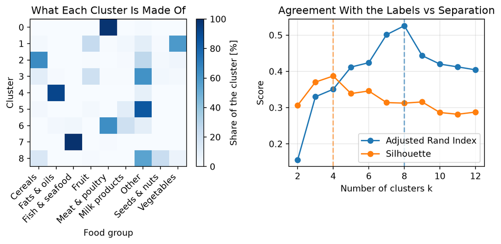

The difference suggests that the reference food groups do not perfectly correspond to the most naturally separated nutritional patterns in the data. While eight clusters provide the closest match to the expert-defined categories, four clusters produce broader groups that are more compact and better separated based on nutritional composition alone. This indicates that some food groups may have similar nutrient profiles and overlap in composition space, even though they are classified as distinct categories.

**TipApplication to Process Data**

Clustering can be used to identify distinct operating modes in process historian data, such as different product grades, seasonal conditions, equipment configurations, or fouling states.

Internal measures such as the silhouette score indicate how well separated the clusters are. However, process knowledge or operator-labelled examples are usually needed to determine whether the clusters correspond to meaningful operating states.

### Task 4 : Describe the clusters

To understand what distinguishes these clusters, we now examine their nutritional composition using the original measurements.

Write a function `describe_clusters` that reports each cluster’s size, dominant reference group, dominant share and three highest mean standardised analyte values.

**TipImplementation guidance**

`X[labels == cluster].mean()` returns one mean value per analyte. Sort the result and select its three largest entries.

`groups[labels == cluster].value_counts()` gives the reference-group counts in descending order.

```
describe_clusters.py
```

```python
def describe_clusters(X, labels, groups):
    """
    Say what each cluster contains, in food groups and in analytes.

    Parameters
    ----------
    X : pd.DataFrame
        The standardised log-transformed analyte table.
    labels : np.ndarray
        The cluster number assigned to each food.
    groups : pd.Series
        The reference food group of each food.

    Returns
    -------
    summary : pd.DataFrame
        One row per cluster, with its size, dominant group and top analytes.
    """
```

When you run this function, it should yield the following output:

summary = describe_clusters(X, kmeans_labels, groups)

Cluster 0 ( 276 foods) Meat & poultry (98%)

high in: Nitrogen (g), C22:5w3 (mg), Zinc (Zn) (mg)

Cluster 1 ( 394 foods) Vegetables (59%)

high in: Vitamin C (mg), Beta-carotene equivalents (provitamin A) (ug), Beta-carotene (ug)

Cluster 2 ( 172 foods) Cereals (65%)

high in: Folic acid (ug), Starch (g), Available carbohydrate, without sugar alcohols (g)

Cluster 3 ( 201 foods) Other (62%)

high in: Alcohol (g), Free sugars (g), Added sugars (g)

Cluster 4 ( 36 foods) Fats & oils (92%)

high in: C18:2w6 (g), C18:3w3 (g), Total polyunsaturated fatty acids, equated (g)

Cluster 5 ( 152 foods) Other (85%)

high in: Added sugars (g), Free sugars (g), Total sugars (g)

Cluster 6 ( 125 foods) Meat & poultry (64%)

high in: Total saturated fatty acids, equated (g), Retinol (preformed vitamin A) (ug), Total monounsaturated fatty acids, equated (g)

Cluster 7 ( 112 foods) Fish & seafood (99%)

high in: C22:6w3 (mg), C20:5w3 (mg), Total long chain omega 3 fatty acids, equated (mg)

Cluster 8 ( 120 foods) Other (55%)

high in: Total dietary fibre (g), Magnesium (Mg) (mg), Iron (Fe) (mg)

The profiles associate clusters with interpretable composition patterns. Examples include meat with nitrogen and zinc, fish with long-chain omega-3 fatty acids, oils with polyunsaturated fats, and cereals with starch and folic acid. Several clusters dominated by `Other` correspond to more coherent composition profiles such as drinks, confectionery, and high-fibre foods. These profiles were obtained without using the food-group labels during fitting.

**Callout-answerAnswer**

```
describe_clusters.py
```

```python
def describe_clusters(X, labels, groups):
    """
    Say what each cluster contains, in food groups and in analytes.

    Parameters
    ----------
    X : pd.DataFrame
        The standardised log-transformed analyte table.
    labels : np.ndarray
        The cluster number assigned to each food.
    groups : pd.Series
        The reference food group of each food.

    Returns
    -------
    summary : pd.DataFrame
        One row per cluster, with its size, dominant group and top analytes.
    """
    rows = []
    for cluster in sorted(set(labels)):
        members = labels == cluster
        dominant = groups[members].value_counts()
        profile = X[members].mean().sort_values()

        rows.append({
            "Size": int(members.sum()),
            "Dominant group": dominant.index[0],
            "Share": f"{100 * dominant.iloc[0] / members.sum():.0f}%",
            "Highest analytes": ", ".join(profile.index[-3:][::-1]),
        })

    summary = pd.DataFrame(rows, index=[f"Cluster {c}" for c in sorted(set(labels))])
    for name, row in summary.iterrows():
        print(f"{name}  ({row['Size']:4d} foods)   {row['Dominant group']} ({row['Share']})")
        print(f"             high in: {row['Highest analytes']}\n")
    return summary

summary = describe_clusters(X, kmeans_labels, groups)
```

Output

```
Cluster 0  ( 276 foods)   Meat & poultry (98%)
             high in: Nitrogen (g), C22:5w3 (mg), Zinc (Zn) (mg)

Cluster 1  ( 394 foods)   Vegetables (59%)
             high in: Vitamin C (mg), Beta-carotene equivalents (provitamin A) (ug), Beta-carotene (ug)

Cluster 2  ( 172 foods)   Cereals (65%)
             high in: Folic acid (ug), Starch (g), Available carbohydrate, without sugar alcohols (g)

Cluster 3  ( 201 foods)   Other (62%)
             high in: Alcohol (g), Free sugars (g), Added sugars (g)

Cluster 4  (  36 foods)   Fats & oils (92%)
             high in: C18:2w6 (g), C18:3w3 (g), Total polyunsaturated fatty acids, equated (g)

Cluster 5  ( 152 foods)   Other (85%)
             high in: Added sugars (g), Free sugars (g), Total sugars (g)

Cluster 6  ( 125 foods)   Meat & poultry (64%)
             high in: Total saturated fatty acids, equated (g), Retinol (preformed vitamin A) (ug), Total monounsaturated fatty acids, equated (g)

Cluster 7  ( 112 foods)   Fish & seafood (99%)
             high in: C22:6w3 (mg), C20:5w3 (mg), Total long chain omega 3 fatty acids, equated (mg)

Cluster 8  ( 120 foods)   Other (55%)
             high in: Total dietary fibre (g), Magnesium (Mg) (mg), Iron (Fe) (mg)
```

## Part B: Density-based clustering with DBSCAN

K-means partitions the data into clusters centred on representative means and assigns every sample to a cluster. This approach works well for compact, roughly spherical clusters, but it may struggle when clusters have irregular shapes or when some samples do not belong clearly to any group.

DBSCAN (*Density-Based Spatial Clustering of Applications with Noise*) takes a different approach. Instead of searching for cluster centres, it identifies regions where samples are densely packed together and labels isolated samples as noise.

**NoteDBSCAN Algorithm**

DBSCAN is controlled by two parameters:

- `eps`: the radius used to define a neighbourhood around each sample;
- `min_samples`: the minimum number of samples required within that neighbourhood for a region to be considered dense.

In scikit-learn, `min_samples` includes the sample itself.

Each sample is classified as one of three types:

| Type | Description |
| --- | --- |
| Core point | Has at least `min_samples` points, including itself, within `eps` |
| Border point | Lies within `eps` of a core point but does not satisfy the core-point criterion |
| Noise point | Does not belong to any dense region |

Clusters are formed from connected core points together with their border points. Noise points are assigned the label `-1`.

DBSCAN has three important advantages:

- the number of clusters is determined automatically from the data;
- clusters can have irregular, non-spherical shapes; and
- isolated samples can be identified as noise rather than being forced into a cluster.

### Task 5 : Estimate `eps`

Set `min_samples = 10`. Before fitting DBSCAN, we need to choose a suitable value of `eps`, the neighbourhood radius used to define dense regions. One common approach is a *neighbourhood-distance plot* (sometimes called a *k-distance plot*). For each food, we measure the distance to the boundary of its 10-sample neighbourhood, sort these distances from smallest to largest, and plot the result. A noticeable change in slope, often called a *knee* or *elbow*, provides a useful initial estimate of `eps`.

**NoteWhy Use `min_samples = 10`?**

There is no single correct value of `min_samples`. Larger values require denser regions before a cluster is formed, while smaller values make the algorithm more sensitive to local structure and noise.

In this tutorial, `min_samples = 10` is used as a reasonable starting value for a dataset containing over 1,500 foods. The resulting neighbourhood-distance plot provides an estimate of `eps`, which can then be refined by inspecting the fitted clusters.

Write a function `plot_k_distance` that measures the distance from each food to the boundary of its 10-sample neighbourhood, sorts these distances, and displays the plot. Because the neighbourhood includes the food itself, this boundary corresponds to the ninth nearest neighbouring food.

**TipImplementation guidance**

`NearestNeighbors(n_neighbors=10).fit(scores)` constructs the neighbour index. Calling `.kneighbors(scores)` returns the distances to the ten nearest neighbours of each food, including the food itself at distance zero. Therefore, `distances[:, -1]` gives the distance to the boundary of the 10-sample neighbourhood.

Use `np.sort` to order these distances before plotting them. Add horizontal lines showing candidate values of `eps` and use the shape of the curve to guide your choice.

For more information, see the [scikit-learn NearestNeighbors documentation](https://scikit-learn.org/stable/modules/generated/sklearn.neighbors.NearestNeighbors.html).

```
plot_k_distance.py
```

```python
def plot_k_distance(scores, min_samples=10):
    """
    Plot the sorted distance to each point's neighbourhood boundary.

    Parameters
    ----------
    scores : np.ndarray
        The component scores, one row per food.
    min_samples : int, optional
        The neighbourhood size, including the point itself (default is 10).

    Returns
    -------
    k_distance : np.ndarray
        The distance from every food to its neighbourhood boundary, unsorted.
    """
```

When you run this function, it should yield the following output:

k_distance = plot_k_distance(scores, min_samples=10)

50% of foods are within 1.77 of their 10-sample neighbourhood boundary

75% of foods are within 2.46 of their 10-sample neighbourhood boundary

90% of foods are within 3.08 of their 10-sample neighbourhood boundary

95% of foods are within 3.66 of their 10-sample neighbourhood boundary

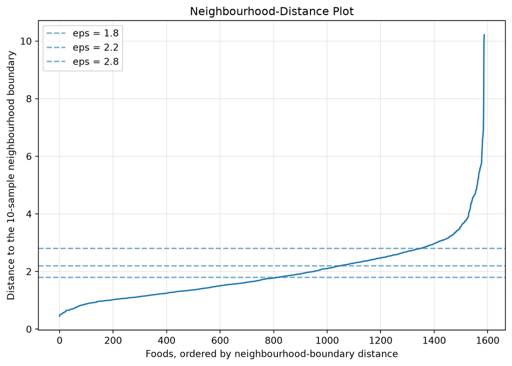

The curve rises gradually before becoming steep near the upper tail. A visual knee near 2.8 produces one dominant connected cluster because chains of core points bridge several dense regions. Reducing `eps` to approximately 1.8 separates these regions. The plot therefore provides a starting value that must be checked against the fitted cluster structure.

**Callout-answerAnswer**

```
plot_k_distance.py
```

```python
def plot_k_distance(scores, min_samples=10):
    """
    Plot the sorted distance to each point's neighbourhood boundary.

    Parameters
    ----------
    scores : np.ndarray
        The component scores, one row per food.
    min_samples : int, optional
        The neighbourhood size, including the point itself (default is 10).

    Returns
    -------
    k_distance : np.ndarray
        The distance from every food to its neighbourhood boundary, unsorted.
    """
    neighbours = NearestNeighbors(n_neighbors=min_samples).fit(scores)
    distances, _ = neighbours.kneighbors(scores)
    k_distance = distances[:, -1]

    for percentile in [50, 75, 90, 95]:
        print(f"{percentile:2d}% of foods are within {np.percentile(k_distance, percentile):.2f} "
              f"of their {min_samples}-sample neighbourhood boundary")

    plt.figure(figsize=(9, 6))
    plt.plot(np.sort(k_distance))
    for candidate in [1.8, 2.2, 2.8]:
        plt.axhline(candidate, linestyle="--", alpha=0.6, label=f"eps = {candidate}")
    plt.xlabel("Foods, ordered by neighbourhood-boundary distance")
    plt.ylabel(f"Distance to the {min_samples}-sample neighbourhood boundary")
    plt.title("Neighbourhood-Distance Plot")
    plt.legend()
    plt.grid(True, alpha=0.3)
    plt.show()
    return k_distance

k_distance = plot_k_distance(scores, min_samples=10)
```

Output

```
50% of foods are within 1.77 of their 10-sample neighbourhood boundary
75% of foods are within 2.46 of their 10-sample neighbourhood boundary
90% of foods are within 3.08 of their 10-sample neighbourhood boundary
95% of foods are within 3.66 of their 10-sample neighbourhood boundary
```

Output

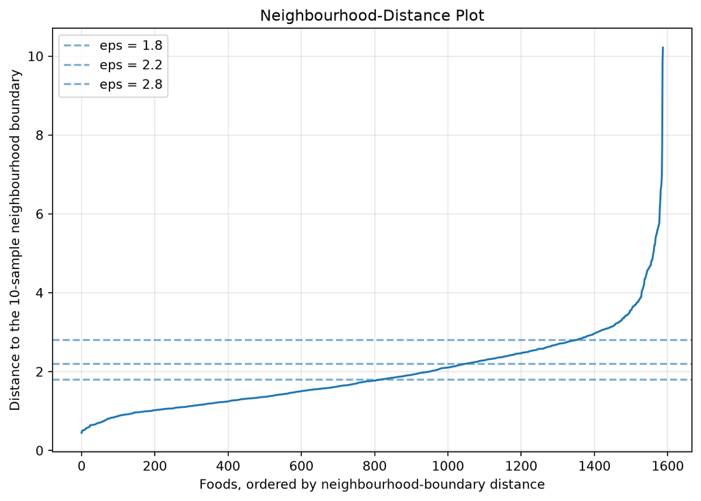

### Task 6 : Fit DBSCAN

Write a function `cluster_dbscan` that fits `DBSCAN`, reports the numbers of clusters and noise points, plots the result, and prints the contingency table used in Part A.

**TipImplementation guidance**

`DBSCAN(eps=eps, min_samples=min_samples).fit_predict(scores)` returns the labels. Cluster numbers begin at 0 and `-1` denotes noise, so the number of clusters is `len(set(labels)) - (1 if -1 in labels else 0)`.

The `plot_clusters` helper displays `-1` in grey. ARI treats all noise points as members of one label, which should be considered when interpreting the score. For more information, see the [scikit-learn DBSCAN documentation](https://scikit-learn.org/stable/modules/generated/sklearn.cluster.DBSCAN.html).

```
cluster_dbscan.py
```

```python
def cluster_dbscan(scores, groups, eps=1.8, min_samples=10):
    """
    Cluster the foods by density and compare the result with the food groups.

    Parameters
    ----------
    scores : np.ndarray
        The component scores, one row per food.
    groups : pd.Series
        The reference food group of each food.
    eps : float, optional
        The neighbourhood radius (default is 1.8).
    min_samples : int, optional
        The minimum neighbourhood size, including the point itself (default is 10).

    Returns
    -------
    labels : np.ndarray
        The cluster number of each food, with -1 for noise.
    """
```

When you run this function, it should yield the following output:

dbscan_labels = cluster_dbscan(scores, groups, eps=1.8, min_samples=10)

Clusters found: 7

Noise points: 565 (35.6% of the foods)

Adjusted Rand Index: 0.337

Food Group Cereals Fats & oils Fish & seafood Fruit Meat & poultry Milk products Other Seeds & nuts Vegetables

row_0

-1 9 3 4 3 10 9 53 6 4

0 13 0 0 23 0 0 21 1 42

1 98 0 0 0 0 0 2 0 0

2 10 0 0 0 0 70 20 0 0

3 0 100 0 0 0 0 0 0 0

4 0 0 0 0 99 0 1 0 0

5 0 0 0 0 100 0 0 0 0

6 0 0 100 0 0 0 0 0 0

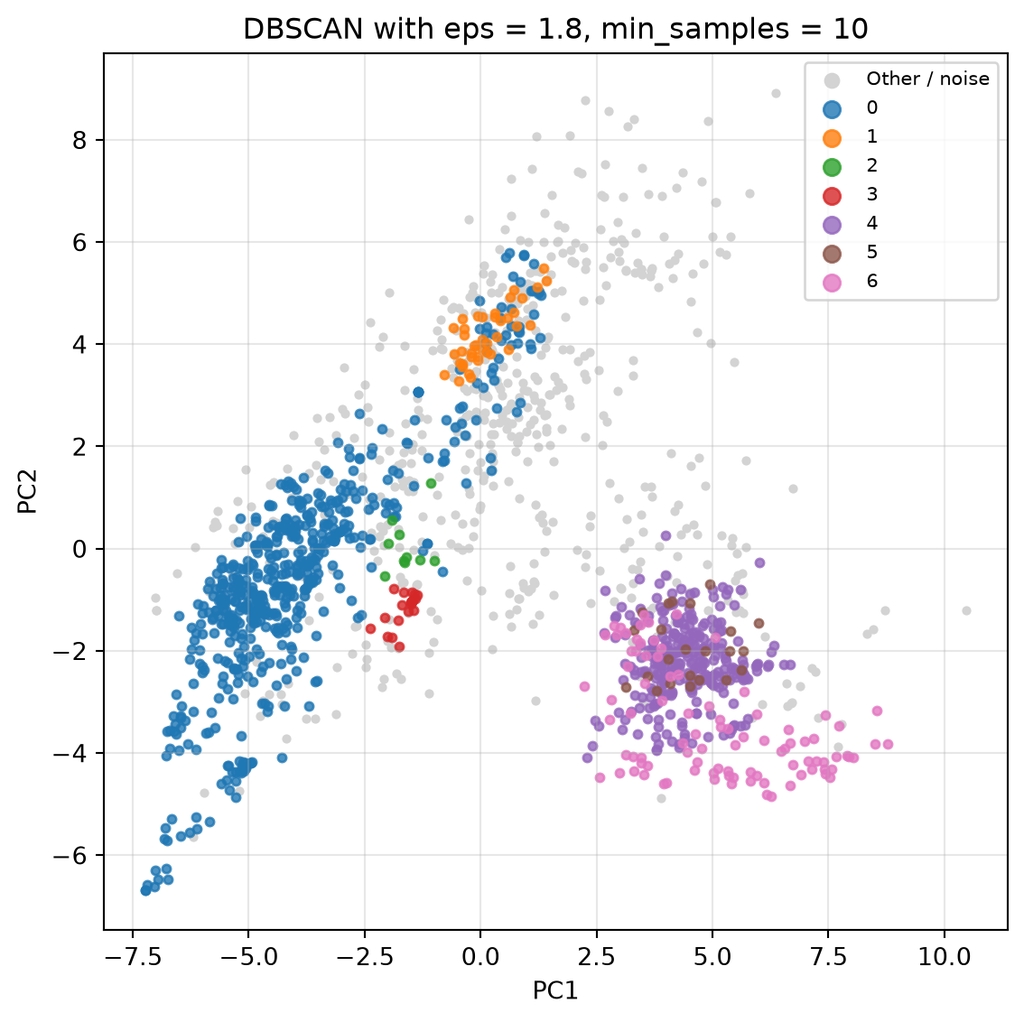

With `eps = 1.8` and `min_samples = 10`, DBSCAN identifies seven clusters and labels 565 foods, or 35.6% of the dataset, as noise. Several clusters are highly concentrated in cereals, fats and oils, fish and seafood, or meat and poultry. A ten-food cluster is 70% milk products, so it contains seven dairy foods. The large mixed plant cluster contains both vegetables and fruit.

The ARI of 0.34 is lower than the K-means result, partly because ARI treats all 565 noise points as one group. The metric therefore does not separately represent DBSCAN’s decision to leave low-density samples unassigned.

**Callout-answerAnswer**

```
cluster_dbscan.py
```

```python
def cluster_dbscan(scores, groups, eps=1.8, min_samples=10):
    """
    Cluster the foods by density and compare the result with the food groups.

    Parameters
    ----------
    scores : np.ndarray
        The component scores, one row per food.
    groups : pd.Series
        The reference food group of each food.
    eps : float, optional
        The neighbourhood radius (default is 1.8).
    min_samples : int, optional
        The minimum neighbourhood size, including the point itself (default is 10).

    Returns
    -------
    labels : np.ndarray
        The cluster number of each food, with -1 for noise.
    """
    labels = DBSCAN(eps=eps, min_samples=min_samples).fit_predict(scores)

    n_clusters = len(set(labels)) - (1 if -1 in labels else 0)
    n_noise = int((labels == -1).sum())
    print(f"Clusters found:  {n_clusters}")
    print(f"Noise points:    {n_noise}  ({100 * n_noise / len(labels):.1f}% of the foods)")
    print(f"Adjusted Rand Index: {adjusted_rand_score(groups, labels):.3f}\n")

    counts = pd.crosstab(labels, groups)
    table = 100 * counts.div(counts.sum(axis=1), axis=0)
    print(table.round(0).astype(int).to_string())

    plot_clusters(scores, labels, f"DBSCAN with eps = {eps}, min_samples = {min_samples}")
    plt.show()
    return labels

dbscan_labels = cluster_dbscan(scores, groups, eps=1.8, min_samples=10)
```

Output

```
Clusters found:  7
Noise points:    565  (35.6% of the foods)
Adjusted Rand Index: 0.337

Food Group  Cereals  Fats & oils  Fish & seafood  Fruit  Meat & poultry  Milk products  Other  Seeds & nuts  Vegetables
row_0
-1                9            3               4      3              10              9     53             6           4
 0               13            0               0     23               0              0     21             1          42
 1               98            0               0      0               0              0      2             0           0
 2               10            0               0      0               0             70     20             0           0
 3                0          100               0      0               0              0      0             0           0
 4                0            0               0      0              99              0      1             0           0
 5                0            0               0      0             100              0      0             0           0
 6                0            0             100      0               0              0      0             0           0
```

Output

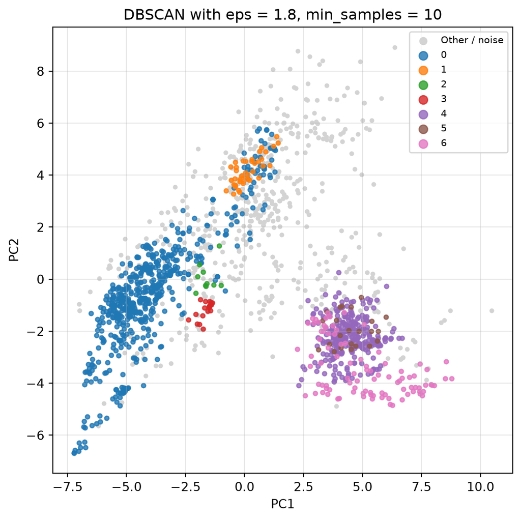

### Task 7 : Inspect the noise points

The noise label identifies foods that are not density-reachable under the selected values of `eps` and `min_samples`.

Write a function `inspect_noise` that ranks the noise foods by neighbourhood-boundary distance and prints the 15 most isolated foods together with the reference-group composition of the noise set.

**TipImplementation guidance**

`np.argsort(-k_distance)` orders foods from largest to smallest neighbourhood-boundary distance. Retain indices with `labels[i] == -1` and select the first 15.

Use `.iloc[i]` for positional indexing of the pandas Series. `groups[labels == -1].value_counts()` gives the reference-group counts.

```
inspect_noise.py
```

```python
def inspect_noise(labels, k_distance, names, groups, n_show=15):
    """
    List the DBSCAN noise points from most to least isolated.

    Parameters
    ----------
    labels : np.ndarray
        The DBSCAN labels, with -1 for noise.
    k_distance : np.ndarray
        The distance from every food to its neighbourhood boundary.
    names : pd.Series
        The name of each food.
    groups : pd.Series
        The food group of each food.
    n_show : int, optional
        How many of the most isolated foods to print (default is 15).

    Returns
    -------
    isolated : list of int
        The indices of the noise foods, most isolated first.
    """
```

When you run this function, it should yield the following output:

isolated = inspect_noise(dbscan_labels, k_distance, names, groups)

The 15 most isolated foods in the database

10.22 Other Spread, yeast, vegemite

9.88 Meat & poultry Lamb, liver, grilled, no added fat

7.76 Vegetables Seaweed, nori, dried

6.92 Other Spread, yeast, marmite

6.79 Other Beverage base, chocolate flavour, added vitamins & m

6.68 Fats & oils Margarine spread, polyunsaturated (~70% fat)

6.63 Other Paprika, dry powder

6.36 Fats & oils Margarine spread, monounsaturated (>65% fat)

6.22 Fats & oils Margarine spread, monounsaturated (>65% fat), reduce

6.00 Other Mayonnaise, traditional (>65% fat), commercial

5.75 Meat & poultry Chicken, liver, raw

5.74 Other Dressing, thousand island, regular fat, commercial

5.69 Meat & poultry Chicken, liver, fried, added butter

5.66 Fats & oils Oil, coconut

5.61 Other Dressing, French or Italian, regular fat, commercial

Food groups among all 565 noise points

Food Group

Other 299

Meat & poultry 54

Cereals 51

Milk products 49

Seeds & nuts 35

Vegetables 22

Fish & seafood 22

Fats & oils 18

Fruit 15

The most isolated noise points include yeast extracts, liver, dried nori, manufactured emulsions and coconut oil. Their compositions differ strongly from common foods in the dataset. A noise label does not imply a measurement error; it depends on the dataset, preprocessing and selected DBSCAN parameters.

**TipReconstruction Error and Isolation**

Tutorial 6 used **reconstruction error** to measure how poorly a PCA model reproduced each sample. In this tutorial, we use **neighbourhood distance** to measure isolation.

These measures identify different types of unusual observations. Reconstruction error detects samples with unusual relationships among variables, whereas neighbourhood distance identifies samples located in sparsely populated regions of the data.

In process monitoring, both measures can be useful because they detect different forms of abnormal behaviour.

**Callout-answerAnswer**

```
inspect_noise.py
```

```python
def inspect_noise(labels, k_distance, names, groups, n_show=15):
    """
    List the DBSCAN noise points from most to least isolated.

    Parameters
    ----------
    labels : np.ndarray
        The DBSCAN labels, with -1 for noise.
    k_distance : np.ndarray
        The distance from every food to its neighbourhood boundary.
    names : pd.Series
        The name of each food.
    groups : pd.Series
        The food group of each food.
    n_show : int, optional
        How many of the most isolated foods to print (default is 15).

    Returns
    -------
    isolated : list of int
        The indices of the noise foods, most isolated first.
    """
    order = np.argsort(-k_distance)
    isolated = [i for i in order if labels[i] == -1]

    print(f"The {n_show} most isolated foods in the database\n")
    for i in isolated[:n_show]:
        print(f"  {k_distance[i]:5.2f}   {groups.iloc[i]:<16} {names.iloc[i][:52]}")

    print(f"\nFood groups among all {len(isolated)} noise points\n")
    print(groups[labels == -1].value_counts().to_string())
    return isolated

isolated = inspect_noise(dbscan_labels, k_distance, names, groups)
```

Output

```
The 15 most isolated foods in the database

  10.22   Other            Spread, yeast, vegemite
   9.88   Meat & poultry   Lamb, liver, grilled, no added fat
   7.76   Vegetables       Seaweed, nori, dried
   6.92   Other            Spread, yeast, marmite
   6.79   Other            Beverage base, chocolate flavour, added vitamins & m
   6.68   Fats & oils      Margarine spread, polyunsaturated (~70% fat)
   6.63   Other            Paprika, dry powder
   6.36   Fats & oils      Margarine spread, monounsaturated (>65% fat)
   6.22   Fats & oils      Margarine spread, monounsaturated (>65% fat), reduce
   6.00   Other            Mayonnaise, traditional (>65% fat), commercial
   5.75   Meat & poultry   Chicken, liver, raw
   5.74   Other            Dressing, thousand island, regular fat, commercial
   5.69   Meat & poultry   Chicken, liver, fried, added butter
   5.66   Fats & oils      Oil, coconut
   5.61   Other            Dressing, French or Italian, regular fat, commercial

Food groups among all 565 noise points

Food Group
Other             299
Meat & poultry     54
Cereals            51
Milk products      49
Seeds & nuts       35
Vegetables         22
Fish & seafood     22
Fats & oils        18
Fruit              15
```

## Part C: Probabilistic clustering with Gaussian mixtures

K-means and DBSCAN assign each food to a single cluster. A Gaussian mixture model takes a probabilistic approach, estimating the probability that each food belongs to each cluster.

This allows foods that lie between clusters to have partial membership in multiple groups rather than being forced into a single assignment. As a result, Gaussian mixtures can model overlapping clusters and provide a measure of uncertainty in the cluster assignments.

**NoteMixture model and responsibility matrix**

A Gaussian mixture model assumes that the data are generated from a collection of Gaussian components. To generate a sample, component $k$ is selected with probability $\pi_k$, after which a sample is drawn from a Gaussian distribution with mean $\boldsymbol{\mu}_k$ and covariance $\boldsymbol{\Sigma}_k$.

The resulting probability density is

$$p(\mathbf{x}) = \sum_{k=1}^{K} \pi_k \, \mathcal{N}(\mathbf{x} \mid \boldsymbol{\mu}_k, \boldsymbol{\Sigma}_k),
\qquad \sum_k \pi_k = 1 .$$

The model parameters are estimated using the **Expectation-Maximisation (EM)** algorithm, which alternates between two steps:

- **E-step:** calculate the probability that each sample belongs to each component:
  $$r_{ik} = \frac{\pi_k \, \mathcal{N}(\mathbf{x}_i \mid \boldsymbol{\mu}_k, \boldsymbol{\Sigma}_k)}{\sum_{j} \pi_j \, \mathcal{N}(\mathbf{x}_i \mid \boldsymbol{\mu}_j, \boldsymbol{\Sigma}_j)} .$$
- **M-step:** update the component parameters using these probabilities as weights.

The values $r_{ik}$ are called **responsibilities**. The responsibility matrix $\mathbf{R}$ contains one row per food and one column per component, with each row summing to one.

Unlike K-means, which assigns each sample to exactly one cluster, a Gaussian mixture model provides **soft assignments**, allowing foods to belong partially to multiple components. This flexibility can better represent overlapping nutritional groups.

### Task 8 : Fit a Gaussian mixture

Write a function `cluster_gmm` that fits a `GaussianMixture`, reports the ARI, plots the clusters with one-standard-deviation component contours, and prints the least certain foods with their two highest component probabilities.

**TipImplementation guidance**

`GaussianMixture(n_components=9, covariance_type="diag", reg_covar=1e-2, random_state=42, n_init=3)` defines the model.

`covariance_type="diag"` restricts each component to an axis-aligned covariance matrix with $p$ variance parameters instead of $p(p+1)/2$ covariance parameters. PCA makes the complete score matrix uncorrelated, but correlations may still exist within individual components. Diagonal covariance is therefore a computational simplification that should be validated for other datasets.

`reg_covar` adds a small positive value to each covariance diagonal to improve numerical stability.

`.predict(scores)` returns the most likely component and `.predict_proba(scores)` returns $\mathbf{R}$. For a diagonal covariance, the plotted ellipse has width and height equal to two standard deviations along PC1 and PC2. In two dimensions this contour contains about 39% of a Gaussian component’s probability mass. For more information, see the [scikit-learn GaussianMixture documentation](https://scikit-learn.org/stable/modules/generated/sklearn.mixture.GaussianMixture.html).

```
cluster_gmm.py
```

```python
def cluster_gmm(scores, names, groups, n_components=9, n_show=8):
    """
    Fit a Gaussian mixture and inspect the foods it is least sure about.

    Parameters
    ----------
    scores : np.ndarray
        The component scores, one row per food.
    names : pd.Series
        The name of each food.
    groups : pd.Series
        The reference food group of each food.
    n_components : int, optional
        The number of mixture components (default is 9).
    n_show : int, optional
        How many uncertain foods to print (default is 8).

    Returns
    -------
    model : GaussianMixture
        The fitted mixture.
    R : np.ndarray
        The responsibility matrix, one row per food and one column per component.
    """
```

When you run this function, it should yield the following output:

gmm, R = cluster_gmm(scores, names, groups, n_components=9)

Adjusted Rand Index: 0.505

Mean confidence: 0.946

Foods below 0.6: 42 (2.6%)

The 8 foods the model is least sure about

component 2 at 0.42, component 6 at 0.30 Pikelet or pancake, sweet, commercial

component 0 at 0.43, component 2 at 0.31 Sauce, tomato, reduced sugar & salt, commerc

component 4 at 0.46, component 2 at 0.42 Lemon, preserved

component 2 at 0.47, component 4 at 0.44 Bean, red kidney, fresh, boiled, drained

component 6 at 0.49, component 2 at 0.48 Breakfast cereal, puffed or popped rice, no

component 2 at 0.49, component 6 at 0.48 Biscuit, savoury, corn cake, plain, salted

component 2 at 0.50, component 4 at 0.48 Tamarind, paste, pure

component 4 at 0.50, component 2 at 0.47 Noodle, soba, dry

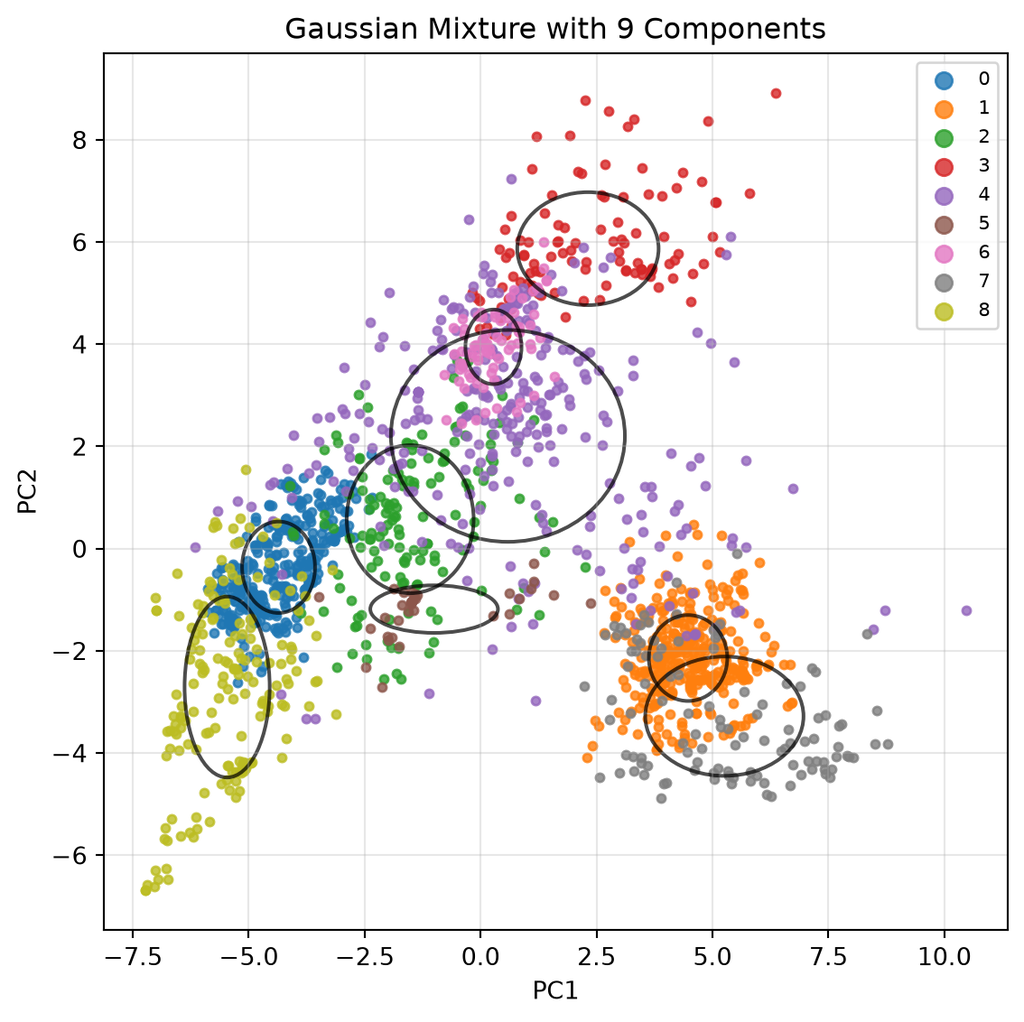

With nine components, the mixture obtains an ARI of 0.51 compared with 0.44 for K-means. Component-specific variances allow broader and narrower regions than K-means can represent. The mean maximum posterior probability is 0.95, while 2.6% of foods have a maximum below 0.6. Low-confidence assignments identify samples near component boundaries and may indicate transitional operating states in process data.

**Callout-answerAnswer**

```
cluster_gmm.py
```

```python
def cluster_gmm(scores, names, groups, n_components=9, n_show=8):
    """
    Fit a Gaussian mixture and inspect the foods it is least sure about.

    Parameters
    ----------
    scores : np.ndarray
        The component scores, one row per food.
    names : pd.Series
        The name of each food.
    groups : pd.Series
        The reference food group of each food.
    n_components : int, optional
        The number of mixture components (default is 9).
    n_show : int, optional
        How many uncertain foods to print (default is 8).

    Returns
    -------
    model : GaussianMixture
        The fitted mixture.
    R : np.ndarray
        The responsibility matrix, one row per food and one column per component.
    """
    model = GaussianMixture(n_components=n_components, covariance_type="diag",
                            reg_covar=1e-2, random_state=42, n_init=3).fit(scores)
    R = model.predict_proba(scores)
    labels = model.predict(scores)
    confidence = R.max(axis=1)

    print(f"Adjusted Rand Index: {adjusted_rand_score(groups, labels):.3f}")
    print(f"Mean confidence:     {confidence.mean():.3f}")
    print(f"Foods below 0.6:     {(confidence < 0.6).sum()}  "
          f"({100 * (confidence < 0.6).mean():.1f}%)\n")

    print(f"The {n_show} foods the model is least sure about\n")
    for i in np.argsort(confidence)[:n_show]:
        first, second = np.argsort(-R[i])[:2]
        print(f"  component {first} at {R[i, first]:.2f}, component {second} at {R[i, second]:.2f}"
              f"   {names.iloc[i][:44]}")

    ax = plot_clusters(scores, labels, f"Gaussian Mixture with {n_components} Components")
    for mean, covariance in zip(model.means_, model.covariances_):
        ax.add_patch(Ellipse(xy=mean[:2], width=2 * np.sqrt(covariance[0]),
                             height=2 * np.sqrt(covariance[1]),
                             fill=False, edgecolor="black", linewidth=1.5, alpha=0.7))
    plt.show()
    return model, R

gmm, R = cluster_gmm(scores, names, groups, n_components=9)
```

Output

```
Adjusted Rand Index: 0.505
Mean confidence:     0.946
Foods below 0.6:     42  (2.6%)

The 8 foods the model is least sure about

  component 2 at 0.42, component 6 at 0.30   Pikelet or pancake, sweet, commercial
  component 0 at 0.43, component 2 at 0.31   Sauce, tomato, reduced sugar & salt, commerc
  component 4 at 0.46, component 2 at 0.42   Lemon, preserved
  component 2 at 0.47, component 4 at 0.44   Bean, red kidney, fresh, boiled, drained
  component 6 at 0.49, component 2 at 0.48   Breakfast cereal, puffed or popped rice, no
  component 2 at 0.49, component 6 at 0.48   Biscuit, savoury, corn cake, plain, salted
  component 2 at 0.50, component 4 at 0.48   Tamarind, paste, pure
  component 4 at 0.50, component 2 at 0.47   Noodle, soba, dry
```

Output

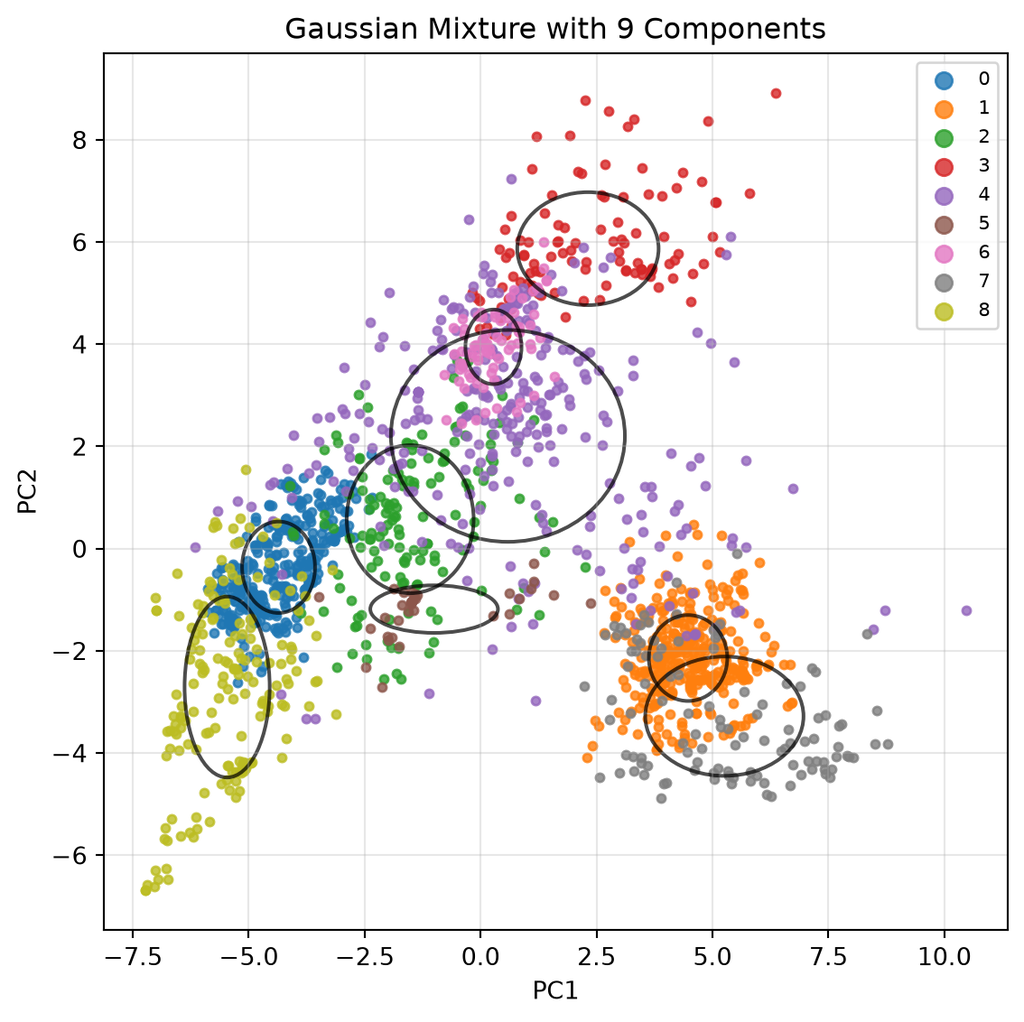

### Task 9 : Assess the number of components

In the previous task, we fitted a Gaussian mixture with nine components to mirror the nine reference food groups. However, as with K-means, there is no guarantee that nine components provides the most appropriate description of the data.

Write a function `choose_components` that fits Gaussian mixtures with different numbers of components and plots the **Bayesian Information Criterion (BIC)** and **Akaike Information Criterion (AIC)**.

**NoteInformation criteria**

Adding more components almost always improves the fit of a Gaussian mixture to the training data. However, a model with too many components may overfit the data by modelling random variation rather than meaningful structure.

The **AIC** and **BIC** balance goodness of fit against model complexity:

$$\text{AIC} = -2\ln\hat{L} + 2m ,
\qquad
\text{BIC} = -2\ln\hat{L} + m\ln n ,$$

where $\hat{L}$ is the maximised likelihood, $m$ is the number of fitted parameters, and $n$ is the number of samples.

Lower values indicate a better trade-off between fit and complexity. For this dataset ($n = 1588$), BIC applies a stronger penalty for additional parameters than AIC and therefore tends to favour simpler models.

**TipImplementation guidance**

Use `model.bic(scores)` and `model.aic(scores)` to evaluate each fitted mixture. Retain the same covariance settings as in the previous task and use `n_init = 3` to reduce sensitivity to random initialisation. This is the most computationally expensive task in the tutorial because several Gaussian mixture models must be fitted.

```
choose_components.py
```

```python
def choose_components(scores, n_values=(2, 4, 6, 8, 9, 10, 12, 15, 20, 25, 30, 40)):
    """
    Score mixtures of different sizes with the information criteria.

    Parameters
    ----------
    scores : np.ndarray
        The component scores, one row per food.
    n_values : iterable of int, optional
        The numbers of components to try.

    Returns
    -------
    best_n : int
        The number of components with the lowest BIC.
    """
```

When you run this function, it should yield the following output:

best_n = choose_components(scores)

2 components BIC 46893 AIC 46737

4 components BIC 43871 AIC 43554

6 components BIC 43002 AIC 42524

8 components BIC 41332 AIC 40693

9 components BIC 41153 AIC 40434

10 components BIC 40842 AIC 40042

12 components BIC 40339 AIC 39377

15 components BIC 39820 AIC 38618

20 components BIC 38931 AIC 37325

25 components BIC 38621 AIC 36613

30 components BIC 38491 AIC 36080

40 components BIC 38424 AIC 35207

Lowest BIC at 40 components

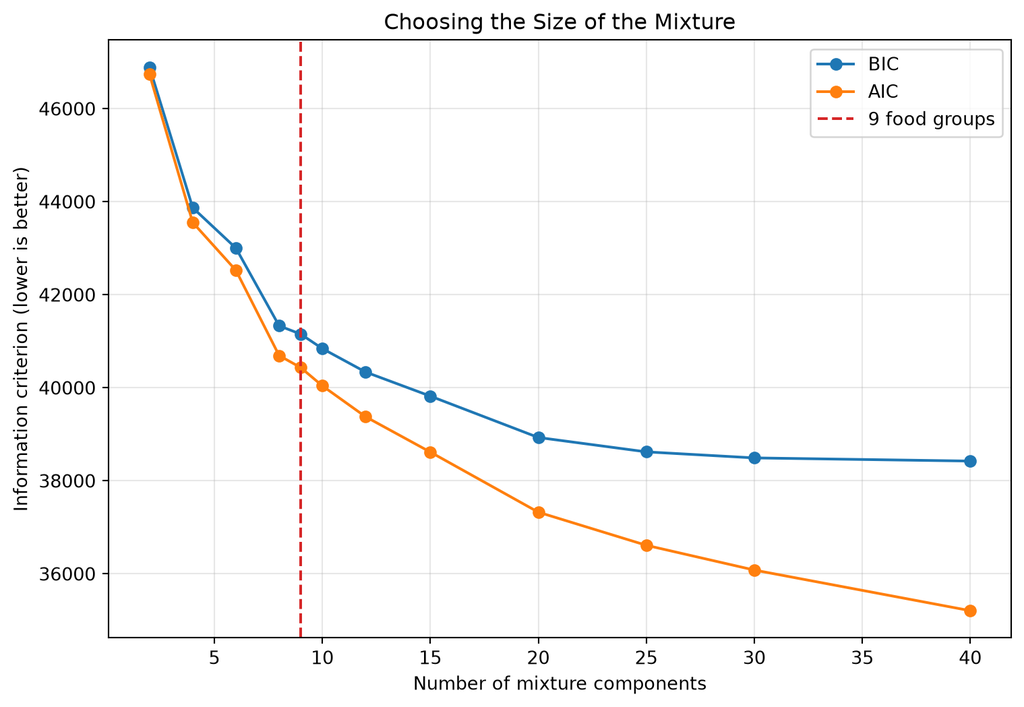

Both criteria decrease through 40 components, so this search does not establish an optimum. The result indicates that the Gaussian components are modelling density shape rather than reproducing the nine reference categories. Non-Gaussian food groups may require several Gaussian components.

The optional extension uses 25 components as a computationally manageable example of over-clustering. This value is illustrative rather than an optimum selected by the displayed BIC curve.

**Callout-answerAnswer**

```
choose_components.py
```

```python
def choose_components(scores, n_values=(2, 4, 6, 8, 9, 10, 12, 15, 20, 25, 30, 40)):
    """
    Score mixtures of different sizes with the information criteria.

    Parameters
    ----------
    scores : np.ndarray
        The component scores, one row per food.
    n_values : iterable of int, optional
        The numbers of components to try.

    Returns
    -------
    best_n : int
        The number of components with the lowest BIC.
    """
    n_values = list(n_values)
    bic, aic = [], []

    for n in n_values:
        model = GaussianMixture(n_components=n, covariance_type="diag", reg_covar=1e-2,
                                random_state=42, n_init=3).fit(scores)
        bic.append(model.bic(scores))
        aic.append(model.aic(scores))
        print(f"{n:2d} components   BIC {bic[-1]:8.0f}   AIC {aic[-1]:8.0f}")

    best_n = n_values[int(np.argmin(bic))]
    print(f"\nLowest BIC at {best_n} components")

    plt.figure(figsize=(9, 6))
    plt.plot(n_values, bic, "o-", label="BIC")
    plt.plot(n_values, aic, "o-", label="AIC")
    plt.axvline(9, color="C3", linestyle="--", label="9 food groups")
    plt.xlabel("Number of mixture components")
    plt.ylabel("Information criterion (lower is better)")
    plt.title("Choosing the Size of the Mixture")
    plt.legend()
    plt.grid(True, alpha=0.3)
    plt.show()
    return best_n

best_n = choose_components(scores)
```

Output

```
 2 components   BIC    46893   AIC    46737
 4 components   BIC    43871   AIC    43554
 6 components   BIC    43002   AIC    42524
 8 components   BIC    41332   AIC    40693
 9 components   BIC    41153   AIC    40434
10 components   BIC    40842   AIC    40042
12 components   BIC    40339   AIC    39377
15 components   BIC    39820   AIC    38618
20 components   BIC    38931   AIC    37325
25 components   BIC    38621   AIC    36613
30 components   BIC    38491   AIC    36080
40 components   BIC    38424   AIC    35207

Lowest BIC at 40 components
```

Output

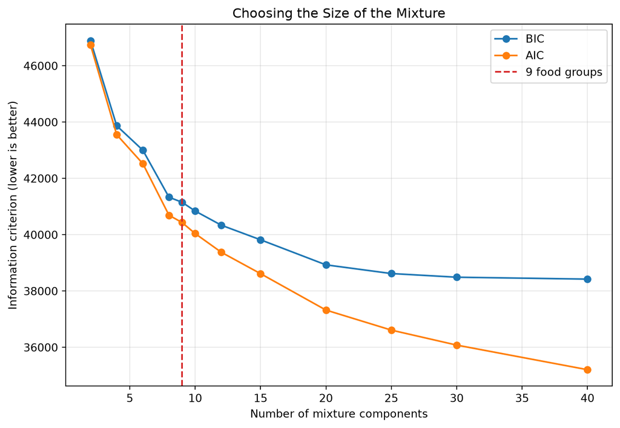

## Optional extension: Learning with limited labels

The core tutorial ends after Part C. Up to this point, we have used clustering methods that do not require labels. In practice, however, a small number of labelled examples are often available.

This extension compares two Gaussian-based approaches for using limited label information. The goal is to investigate how much can be learned when only a subset of the training foods has known food-group labels.

**NoteModels compared**

The two methods use Gaussian densities differently:

| Method | Gaussian structure | Use of labels |
| --- | --- | --- |
| Supervised Gaussian classifier | One diagonal Gaussian per food group | Labels determine which samples estimate each group distribution |
| Component-mapping method | A 25-component unsupervised mixture followed by a component-to-group map | Labels estimate the map after the mixture has been fitted |

The supervised method estimates one class-conditional Gaussian distribution for each food group. Prediction is based on the group with the highest prior-weighted density:

$$\hat{y} = \arg\max_{k} \; \pi_k \, \mathcal{N}(\mathbf{x} \mid \boldsymbol{\mu}_k, \boldsymbol{\Sigma}_k)$$

The component-mapping method takes a different approach. First, an unsupervised Gaussian mixture is fitted using all available foods, regardless of whether labels are known. A small labelled subset is then used to determine which food groups are associated with the mixture components.

Because a food group may contain several nutritional subtypes, multiple components may map to the same food group. This approach is therefore a simple semi-supervised strategy rather than a semi-supervised version of the EM algorithm.

To evaluate these approaches fairly, the raw data are split into training and test sets before feature selection, scaling, and PCA. Complete analyte columns are selected using only the training data, and all preprocessing steps are fitted on the training set before being applied to the test set. This prevents information from the test set leaking into the fitted representation and provides an unbiased assessment of predictive performance.

```
split_food_data.py
```

```python
CATEGORIES = sorted(groups.unique())
y = pd.Categorical(groups, categories=CATEGORIES).codes

part_d_data = pd.read_csv('data/ausnat_food_composition.csv')
measurements = part_d_data.drop(columns=LABELS)
row_ids = np.arange(len(y))

train_rows, test_rows = train_test_split(
    row_ids, test_size=0.3, random_state=42, stratify=y)
y_train, y_test = y[train_rows], y[test_rows]

train_measurements = measurements.iloc[train_rows].dropna(axis=1)
test_measurements = measurements.iloc[test_rows][train_measurements.columns]
log_train = np.log1p(train_measurements)
log_test = np.log1p(test_measurements)

part_d_scaler = StandardScaler().fit(log_train)
X_train = part_d_scaler.transform(log_train)
X_test = part_d_scaler.transform(log_test)

part_d_pca = PCA(n_components=7, random_state=42).fit(X_train)
scores_train = part_d_pca.transform(X_train)
scores_test = part_d_pca.transform(X_test)

print(f"Training foods: {len(y_train)}")
print(f"Testing foods:  {len(y_test)}")
```

Output

```
Training foods: 1111
Testing foods:  477
```

When you run this function, it should yield the following output:

print(f"Training foods: {len(y_train)}")

Training foods: 1111

print(f"Testing foods: {len(y_test)}")

Testing foods: 477

`stratify=y` approximately preserves the food-group proportions in the training and test sets.

### Task 10 : Fit the supervised Gaussian classifier

Write `fit_supervised_gmm` to fit one diagonal Gaussian per food group and estimate the group frequencies. Write `predict_gmm` to classify new foods using the prior-weighted Gaussian densities. Report the test accuracy and confusion matrix.

**TipImplementation guidance**

A one-component `GaussianMixture` can estimate the mean and diagonal covariance for each group. Fit it separately to `scores_train[y_train == c]` for each class `c`.

`component.score_samples(scores)` returns log densities. Add the log prior for each group, combine the columns with `np.column_stack`, and use `np.argmax(..., axis=1)` for prediction.

Use `confusion_matrix(y_test, predictions)` for group-level error analysis.

```
fit_supervised_gmm.py
```

```python
def fit_supervised_gmm(scores_labelled, y_labelled, n_classes=9):
    """
    Fit one diagonal Gaussian per class.

    Parameters
    ----------
    scores_labelled : np.ndarray
        The component scores of the labelled foods.
    y_labelled : np.ndarray
        The integer class code of each labelled food.
    n_classes : int, optional
        The number of classes (default is 9).

    Returns
    -------
    components : list of GaussianMixture
        One single-component mixture per class.
    priors : np.ndarray
        The fraction of the labelled data in each class.
    """


def predict_gmm(scores, components, priors):
    """
    Classify foods by which class Gaussian makes them most likely.

    Parameters
    ----------
    scores : np.ndarray
        The component scores of the foods to classify.
    components : list of GaussianMixture
        One single-component mixture per class.
    priors : np.ndarray
        The fraction of the labelled data in each class.

    Returns
    -------
    predictions : np.ndarray
        The predicted class code of each food.
    """
```

When you run this function, it should yield the following output:

components, priors = report_supervised(scores_train, y_train, scores_test, y_test)

Test accuracy: 0.801

Cereals Fats & oi Fish & se Fruit Meat & po Milk prod Other Seeds & n Vegetable

Cereals 33 0 0 0 0 0 12 2 2

Fats & oils 0 11 0 0 0 0 0 0 0

Fish & seafood 0 0 34 0 0 0 0 0 0

Fruit 0 0 0 29 0 0 6 0 8

Meat & poultry 1 0 0 0 101 1 4 0 0

Milk products 1 0 0 0 0 13 3 0 0

Other 9 1 0 5 1 9 88 10 5

Seeds & nuts 0 0 0 0 0 0 2 9 1

Vegetables 1 0 0 8 0 0 3 0 64

Recall by group

Cereals 0.67 (n = 49)

Fats & oils 1.00 (n = 11)

Fish & seafood 1.00 (n = 34)

Fruit 0.67 (n = 43)

Meat & poultry 0.94 (n = 107)

Milk products 0.76 (n = 17)

Other 0.69 (n = 128)

Seeds & nuts 0.75 (n = 12)

Vegetables 0.84 (n = 76)

The supervised model obtains 0.801 test accuracy. Fats and oils and fish and seafood are classified perfectly, while meat and poultry has 0.94 recall. Cereals, fruit and `Other` have lower recall because their composition regions overlap. This fully labelled training result provides a reference for the limited-label comparisons.

**Callout-answerAnswer**

```
fit_supervised_gmm.py
```

```python
def fit_supervised_gmm(scores_labelled, y_labelled, n_classes=9):
    """
    Fit one diagonal Gaussian per class.

    Parameters
    ----------
    scores_labelled : np.ndarray
        The component scores of the labelled foods.
    y_labelled : np.ndarray
        The integer class code of each labelled food.
    n_classes : int, optional
        The number of classes (default is 9).

    Returns
    -------
    components : list of GaussianMixture
        One single-component mixture per class.
    priors : np.ndarray
        The fraction of the labelled data in each class.
    """
    components = [
        GaussianMixture(n_components=1, covariance_type="diag", reg_covar=1e-2)
        .fit(scores_labelled[y_labelled == c])
        for c in range(n_classes)
    ]
    priors = np.array([(y_labelled == c).mean() for c in range(n_classes)])
    return components, priors


def predict_gmm(scores, components, priors):
    """
    Classify foods by which class Gaussian makes them most likely.

    Parameters
    ----------
    scores : np.ndarray
        The component scores of the foods to classify.
    components : list of GaussianMixture
        One single-component mixture per class.
    priors : np.ndarray
        The fraction of the labelled data in each class.

    Returns
    -------
    predictions : np.ndarray
        The predicted class code of each food.
    """
    log_likelihood = np.column_stack([
        np.log(prior + 1e-300) + component.score_samples(scores)
        for component, prior in zip(components, priors)
    ])
    return np.argmax(log_likelihood, axis=1)


components, priors = fit_supervised_gmm(scores_train, y_train)
predictions = predict_gmm(scores_test, components, priors)

print(f"Test accuracy: {accuracy_score(y_test, predictions):.3f}\n")

cm = confusion_matrix(y_test, predictions)
print(pd.DataFrame(cm, index=CATEGORIES,
                   columns=[c[:9] for c in CATEGORIES]).to_string())

print("\nRecall by group\n")
for i, category in enumerate(CATEGORIES):
    print(f"  {category:<16} {cm[i, i] / cm[i].sum():.2f}   (n = {cm[i].sum()})")
```

Output

```
Test accuracy: 0.801

                Cereals  Fats & oi  Fish & se  Fruit  Meat & po  Milk prod  Other  Seeds & n  Vegetable
Cereals              33          0          0      0          0          0     12          2          2
Fats & oils           0         11          0      0          0          0      0          0          0
Fish & seafood        0          0         34      0          0          0      0          0          0
Fruit                 0          0          0     29          0          0      6          0          8
Meat & poultry        1          0          0      0        101          1      4          0          0
Milk products         1          0          0      0          0         13      3          0          0
Other                 9          1          0      5          1          9     88         10          5
Seeds & nuts          0          0          0      0          0          0      2          9          1
Vegetables            1          0          0      8          0          0      3          0         64

Recall by group

  Cereals          0.67   (n = 49)
  Fats & oils      1.00   (n = 11)
  Fish & seafood   1.00   (n = 34)
  Fruit            0.67   (n = 43)
  Meat & poultry   0.94   (n = 107)
  Milk products    0.76   (n = 17)
  Other            0.69   (n = 128)
  Seeds & nuts     0.75   (n = 12)
  Vegetables       0.84   (n = 76)
```

### Task 11 : Fit the component-mapping model

Suppose that only a small balanced subset of the training foods is labelled. The mixture can still be fitted to all training scores while ignoring their labels.

Write `fit_semi_supervised_gmm` to fit an unsupervised mixture to all training scores and then estimate a component-to-group map from the labelled subset. Write `predict_semi_supervised` to classify with the fitted mixture and map.

**NoteMapping components to groups**

The mixture has more components than reference groups, so several components may describe different regions of the same group. Define a matrix $\mathbf{M}$ with one row per component and one column per group. The value $M_{kc}$ estimates the conditional probability of group $c$ given component $k$.

Estimate the unnormalised entries by summing labelled-sample responsibilities within each group:

$$M_{kc} \;\propto\; \sum_{i \,\in\, \text{labelled},\; y_i = c} r_{ik}$$

Normalise each row to sum to one. Prediction then uses

$$\hat{y} = \arg\max_{c} \; (\mathbf{R}\mathbf{M})_{\cdot c},$$

The product $\mathbf{R}\mathbf{M}$ combines component probabilities with the estimated component-to-group map. Labels affect the map but not the fitted component means or covariances.

**TipImplementation guidance**

`model.predict_proba(scores_labelled)` gives the responsibilities of the labelled foods. For class `c`, `R_labelled[y_labelled == c].sum(axis=0)` produces one column of $\mathbf{M}$ before normalisation.

Add a small smoothing constant so that components with no labelled representatives retain valid rows. Use `M.sum(axis=1, keepdims=True)` for row normalisation.

```
fit_semi_supervised_gmm.py
```

```python
def fit_semi_supervised_gmm(scores_all, scores_labelled, y_labelled,
                            n_components=25, n_classes=9, random_state=42):
    """
    Fit a mixture to all training scores, then map its components with a few labels.

    Parameters
    ----------
    scores_all : np.ndarray
        The component scores of every training food. Labels are not used in the fit.
    scores_labelled : np.ndarray
        The component scores of the few labelled foods.
    y_labelled : np.ndarray
        The integer class code of each labelled food.
    n_components : int, optional
        The size of the mixture (default is 25).
    n_classes : int, optional
        The number of classes (default is 9).
    random_state : int, optional
        The seed for the mixture fit (default is 42).

    Returns
    -------
    model : GaussianMixture
        The mixture, fitted without using any labels.
    M : np.ndarray
        The component-to-class map, one row per component.
    """


def predict_semi_supervised(scores, model, M):
    """
    Classify foods by multiplying their responsibilities through the class map.

    Parameters
    ----------
    scores : np.ndarray
        The component scores of the foods to classify.
    model : GaussianMixture
        The fitted mixture.
    M : np.ndarray
        The component-to-class map.

    Returns
    -------
    predictions : np.ndarray
        The predicted class code of each food.
    """
```

When you run this function, it should yield the following output:

semi_model, M = report_semi_supervised(n_per_class=5)

Labelled foods used: 45 of 1111 (4.1%)

Test accuracy: 0.646

What each component is called, for the first 10 components

component 0 -> Vegetables (confidence 0.68)

component 1 -> Meat & poultry (confidence 1.00)

component 2 -> Meat & poultry (confidence 1.00)

component 3 -> Cereals (confidence 0.50)

component 4 -> Cereals (confidence 0.94)

component 5 -> Seeds & nuts (confidence 0.43)

component 6 -> Seeds & nuts (confidence 0.11)

component 7 -> Fats & oils (confidence 1.00)

component 8 -> Fish & seafood (confidence 1.00)

component 9 -> Other (confidence 0.99)

The seeded example obtains 0.646 accuracy using 45 labels, corresponding to five selected examples from each group. Several mixture components can map to the same reference group, allowing a non-Gaussian group to be represented by multiple local Gaussian regions. Repeated sampling is required because a single labelled subset may not be representative.

**Callout-answerAnswer**

```
fit_semi_supervised_gmm.py
```

```python
def fit_semi_supervised_gmm(scores_all, scores_labelled, y_labelled,
                            n_components=25, n_classes=9, random_state=42):
    """
    Fit a mixture to all training scores, then map its components with a few labels.

    Parameters
    ----------
    scores_all : np.ndarray
        The component scores of every training food. Labels are not used in the fit.
    scores_labelled : np.ndarray
        The component scores of the few labelled foods.
    y_labelled : np.ndarray
        The integer class code of each labelled food.
    n_components : int, optional
        The size of the mixture (default is 25).
    n_classes : int, optional
        The number of classes (default is 9).
    random_state : int, optional
        The seed for the mixture fit (default is 42).

    Returns
    -------
    model : GaussianMixture
        The mixture, fitted without using any labels.
    M : np.ndarray
        The component-to-class map, one row per component.
    """
    model = GaussianMixture(n_components=n_components, covariance_type="diag",
                            reg_covar=1e-2, random_state=random_state,
                            n_init=3).fit(scores_all)

    R_labelled = model.predict_proba(scores_labelled)
    M = np.column_stack([R_labelled[y_labelled == c].sum(axis=0) for c in range(n_classes)])
    M = (M + 1e-6) / (M + 1e-6).sum(axis=1, keepdims=True)
    return model, M


def predict_semi_supervised(scores, model, M):
    """
    Classify foods by multiplying their responsibilities through the class map.

    Parameters
    ----------
    scores : np.ndarray
        The component scores of the foods to classify.
    model : GaussianMixture
        The fitted mixture.
    M : np.ndarray
        The component-to-class map.

    Returns
    -------
    predictions : np.ndarray
        The predicted class code of each food.
    """
    return np.argmax(model.predict_proba(scores) @ M, axis=1)


rng = np.random.default_rng(0)
labelled = np.hstack([rng.choice(np.where(y_train == c)[0], 5, replace=False)
                      for c in range(9)])

semi_model, M = fit_semi_supervised_gmm(scores_train, scores_train[labelled], y_train[labelled])
predictions = predict_semi_supervised(scores_test, semi_model, M)

print(f"Labelled foods used:  {len(labelled)} of {len(y_train)} "
      f"({100 * len(labelled) / len(y_train):.1f}%)")
print(f"Test accuracy:        {accuracy_score(y_test, predictions):.3f}\n")

print("What each component is called, for the first 10 components\n")
for k in range(10):
    print(f"  component {k:2d} -> {CATEGORIES[M[k].argmax()]:<16} "
          f"(confidence {M[k].max():.2f})")
```

Output

```
Labelled foods used:  45 of 1111 (4.1%)
Test accuracy:        0.646

What each component is called, for the first 10 components

  component  0 -> Vegetables       (confidence 0.68)
  component  1 -> Meat & poultry   (confidence 1.00)
  component  2 -> Meat & poultry   (confidence 1.00)
  component  3 -> Cereals          (confidence 0.50)
  component  4 -> Cereals          (confidence 0.94)
  component  5 -> Seeds & nuts     (confidence 0.43)
  component  6 -> Seeds & nuts     (confidence 0.11)
  component  7 -> Fats & oils      (confidence 1.00)
  component  8 -> Fish & seafood   (confidence 1.00)
  component  9 -> Other            (confidence 0.99)
```

### Task 12 : Compare equal label budgets

Compare both approaches using the same number of labelled examples from each food group.

Write a function `label_budget_curve` that repeatedly selects a balanced labelled subset, fits both methods using the same subset, and reports mean test accuracy. Plot the mean accuracies with the fully supervised result as a reference.

**TipExperimental design**

`rng.choice(np.where(y_train == c)[0], n, replace=False)` selects `n` training foods from group `c`. The resulting balanced design assumes that examples can be deliberately obtained from every group. It is not equivalent to labelling a simple random sample from an unknown population.

The supervised model estimates group priors from the labelled subset. Balanced selection therefore gives equal estimated priors and isolates the effect of estimating each group distribution from limited data.

The unsupervised mixture does not depend on the labelled subset, so fit one mixture per repeat and reuse it across label budgets. Only the component-to-group map changes.

With one labelled sample per group, the supervised Gaussian model cannot estimate a within-group variance. Record its accuracy as `np.nan` for that budget.

```
label_budget_curve.py
```

```python
def label_budget_curve(scores_train, y_train, scores_test, y_test,
                       budgets=(1, 2, 3, 5, 10, 15, 25), n_repeats=10):
    """
    Compare the supervised and semi-supervised models at equal label budgets.

    Parameters
    ----------
    scores_train, scores_test : np.ndarray
        The component scores of the training and testing foods.
    y_train, y_test : np.ndarray
        The class codes of the training and testing foods.
    budgets : iterable of int, optional
        The numbers of labelled foods per group to try.
    n_repeats : int, optional
        How many random labelled sets to average over (default is 10).

    Returns
    -------
    results : pd.DataFrame
        The mean accuracy of each approach at each budget.
    """
```

When you run this function, it should yield the following output:

results = label_budget_curve(scores_train, y_train, scores_test, y_test)

Labels in total Supervised Semi-supervised

Labels per group

1 9 NaN 0.486

2 18 0.340 0.589

3 27 0.538 0.622

5 45 0.596 0.630

10 90 0.694 0.669

15 135 0.724 0.687

25 225 0.749 0.714

Fully supervised, all 1111 labels: 0.801

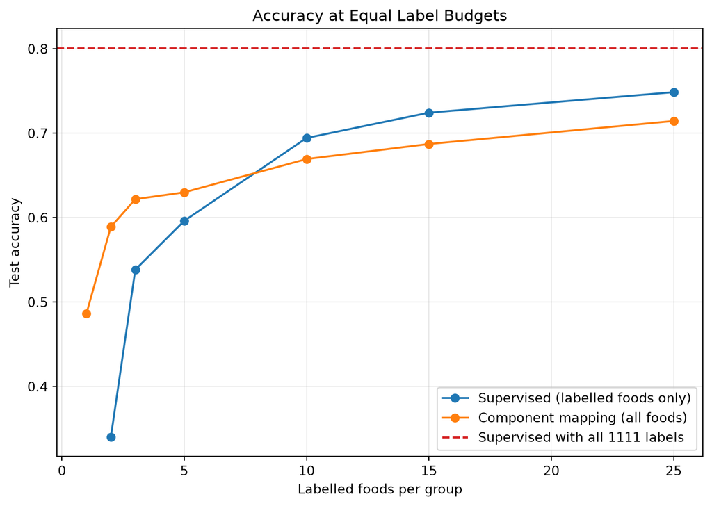

With one label per group, the supervised model cannot estimate within-group variances. The component-mapping method obtains a mean accuracy of 0.486 because its Gaussian components were fitted using all training scores.

The component-mapping method performs better from two to five labels per group. At two labels per group, its mean accuracy is 0.589 compared with 0.340 for the supervised model. The ordering reverses at ten labels per group, where the supervised and component-mapping accuracies are 0.694 and 0.669, respectively. With sufficient labels, direct estimation of the reference-group distributions is more effective than mapping an unsupervised density model onto those groups.

**TipApplication to process data**

Industrial historians often contain many unlabelled observations and few confirmed operating states or fault events. Unsupervised components can support an initial labelling strategy when examples are scarce. Representative samples from different components may then be prioritised for expert review. This is one form of cluster-informed active learning, but its benefit should be evaluated for the specific process and labelling procedure.

**Callout-answerAnswer**

```
label_budget_curve.py
```

```python
def label_budget_curve(scores_train, y_train, scores_test, y_test,
                       budgets=(1, 2, 3, 5, 10, 15, 25), n_repeats=10):
    """
    Compare the supervised and semi-supervised models at equal label budgets.

    Parameters
    ----------
    scores_train, scores_test : np.ndarray
        The component scores of the training and testing foods.
    y_train, y_test : np.ndarray
        The class codes of the training and testing foods.
    budgets : iterable of int, optional
        The numbers of labelled foods per group to try.
    n_repeats : int, optional
        How many random labelled sets to average over (default is 10).

    Returns
    -------
    results : pd.DataFrame
        The mean accuracy of each approach at each budget.
    """
    budgets = list(budgets)
    n_classes = len(np.unique(y_train))

    # The mixture fit does not depend on the labelled subset.
    mixtures = [GaussianMixture(n_components=25, covariance_type="diag",
                                reg_covar=1e-2, random_state=seed,
                                n_init=3).fit(scores_train)
                for seed in range(n_repeats)]

    rows = []
    for n_per_class in budgets:
        supervised, semi = [], []

        for seed in range(n_repeats):
            rng = np.random.default_rng(seed)
            labelled = np.hstack([rng.choice(np.where(y_train == c)[0], n_per_class,
                                             replace=False) for c in range(n_classes)])
            scores_labelled, y_labelled = scores_train[labelled], y_train[labelled]

            # A covariance needs at least two points, so one label per group is
            # not enough to fit the supervised model at all.
            if n_per_class >= 2:
                model = fit_supervised_gmm(scores_labelled, y_labelled)
                supervised.append(accuracy_score(y_test, predict_gmm(scores_test, *model)))

            mixture = mixtures[seed]
            R_labelled = mixture.predict_proba(scores_labelled)
            M = np.column_stack([R_labelled[y_labelled == c].sum(axis=0)
                                 for c in range(n_classes)])
            M = (M + 1e-6) / (M + 1e-6).sum(axis=1, keepdims=True)
            semi.append(accuracy_score(y_test, predict_semi_supervised(scores_test, mixture, M)))

        rows.append({"Labels per group": n_per_class,
                     "Labels in total": n_per_class * n_classes,
                     "Supervised": np.mean(supervised) if supervised else np.nan,
                     "Semi-supervised": np.mean(semi)})

    results = pd.DataFrame(rows).set_index("Labels per group")
    print(results.round(3).to_string())

    ceiling = accuracy_score(y_test, predict_gmm(scores_test,
                                                 *fit_supervised_gmm(scores_train, y_train)))
    print(f"\nFully supervised, all {len(y_train)} labels: {ceiling:.3f}")

    plt.figure(figsize=(9, 6))
    plt.plot(budgets, results["Supervised"], "o-", label="Supervised (labelled foods only)")
    plt.plot(budgets, results["Semi-supervised"], "o-", label="Component mapping (all foods)")
    plt.axhline(ceiling, color="C3", linestyle="--",
                label=f"Supervised with all {len(y_train)} labels")
    plt.xlabel("Labelled foods per group")
    plt.ylabel("Test accuracy")
    plt.title("Accuracy at Equal Label Budgets")
    plt.legend()
    plt.grid(True, alpha=0.3)
    plt.show()
    return results

results = label_budget_curve(scores_train, y_train, scores_test, y_test)
```

Output

```
                  Labels in total  Supervised  Semi-supervised
Labels per group
1                               9         NaN            0.486
2                              18       0.340            0.589
3                              27       0.538            0.622
5                              45       0.596            0.630
10                             90       0.694            0.669
15                            135       0.724            0.687
25                            225       0.749            0.714

Fully supervised, all 1111 labels: 0.801
```

Output

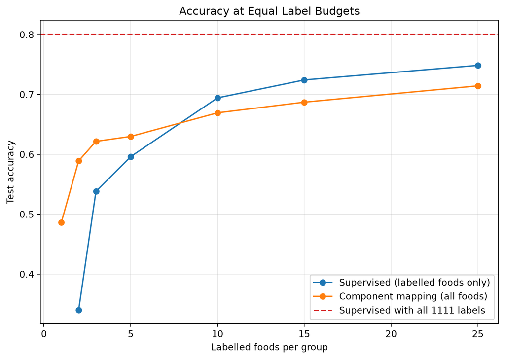

## Conclusion

The three clustering methods describe different structures in the same food-composition data:

| Method | Main result | Main limitation |
| --- | --- | --- |
| K-means | Compact clusters with an ARI of 0.44 at $k=9$ | Requires $k$ and assigns every sample |
| DBSCAN | Seven dense regions and 35.6% noise | Sensitive to `eps` and density variation |
| Gaussian mixture | Probabilistic assignments with an ARI of 0.51 at nine components | Assumes a Gaussian component structure |

Internal measures such as silhouette assess separation, while external measures such as ARI assess agreement with reference labels. Neither measure establishes a universally correct clustering.

The optional extension shows that a component-to-group map can be useful when labels are scarce. As the label budget increases, direct supervised estimation eventually becomes more accurate. This comparison depends on the balanced sampling design and should not be generalised without validation on the intended application.

## Sources

- [Clustering in scikit-learn](https://scikit-learn.org/stable/modules/clustering.html)
- [KMeans](https://scikit-learn.org/stable/modules/generated/sklearn.cluster.KMeans.html)
- [DBSCAN](https://scikit-learn.org/stable/modules/generated/sklearn.cluster.DBSCAN.html)
- [Gaussian mixture models](https://scikit-learn.org/stable/modules/mixture.html)
- [GaussianMixture](https://scikit-learn.org/stable/modules/generated/sklearn.mixture.GaussianMixture.html)
- [silhouette_score](https://scikit-learn.org/stable/modules/generated/sklearn.metrics.silhouette_score.html)
- [adjusted_rand_score](https://scikit-learn.org/stable/modules/generated/sklearn.metrics.adjusted_rand_score.html)
- [NearestNeighbors](https://scikit-learn.org/stable/modules/generated/sklearn.neighbors.NearestNeighbors.html)
- [Demonstration of k-means assumptions](https://scikit-learn.org/stable/auto_examples/cluster/plot_kmeans_assumptions.html)
- [Comparing different clustering algorithms](https://scikit-learn.org/stable/auto_examples/cluster/plot_cluster_comparison.html)
- [Australian Food Composition Database](https://www.foodstandards.gov.au/science-data/food-composition-databases)